# Michelin restaurants in the world

The subject of this notebook is the analysis of restaurants that can pride themselves on a star (or stars) awarded by Michelin. The dataset is downloaded from https://www.kaggle.com/jackywang529/michelin-restaurants and it is divided into three csv files. Each of them shows the restaurants (and their details) which were awarded with one, two and three stars respectively.

It is necessary to announce that the dataset does not contain the list of all of the restaurants with Michelin star. In the list there are no restauarants that are located i.a. in Germany, Spain or Italy.

## Data cleaning

```python
import pandas as pd
```

```python
michelin_1_df = pd.read_csv(r'C:\Users\ASUS\Desktop\Programming\Python\Michelin_project\michelin1.csv')
michelin_2_df = pd.read_csv(r'C:\Users\ASUS\Desktop\Programming\Python\Michelin_project\michelin2.csv')
michelin_3_df = pd.read_csv(r'C:\Users\ASUS\Desktop\Programming\Python\Michelin_project\michelin3.csv')
```

```python
michelin_1_df
```

|  | name | year | latitude | longitude | city | region | zipCode | cuisine | price | url |
| --- | --- | --- | --- | --- | --- | --- | --- | --- | --- | --- |
| 0 | Kilian Stuba | 2019 | 47.348580 | 10.171140 | Kleinwalsertal | Austria | 87568 | Creative | $$$$$ | https://guide.michelin.com/at/en/vorarlberg/kl... |
| 1 | Pfefferschiff | 2019 | 47.837870 | 13.079170 | Hallwang | Austria | 5300 | Classic cuisine | $$$$$ | https://guide.michelin.com/at/en/salzburg-regi... |
| 2 | Esszimmer | 2019 | 47.806850 | 13.034090 | Salzburg | Austria | 5020 | Creative | $$$$$ | https://guide.michelin.com/at/en/salzburg-regi... |
| 3 | Carpe Diem | 2019 | 47.800010 | 13.040060 | Salzburg | Austria | 5020 | Market cuisine | $$$$$ | https://guide.michelin.com/at/en/salzburg-regi... |
| 4 | Edvard | 2019 | 48.216503 | 16.368520 | Wien | Austria | 1010 | Modern cuisine | $$$$ | https://guide.michelin.com/at/en/vienna/wien/r... |
| ... | ... | ... | ... | ... | ... | ... | ... | ... | ... | ... |
| 544 | The Sportsman | 2019 | 51.343920 | 0.958850 | Seasalter | United Kingdom | CT5 4BP | Modern British | NaN | https://guide.michelin.com/gb/en/kent/seasalte... |
| 545 | West House | 2019 | 51.115210 | 0.642150 | Biddenden | United Kingdom | TN27 8AH | Modern British | NaN | https://guide.michelin.com/gb/en/kent/biddende... |
| 546 | Fordwich Arms | 2019 | 51.295284 | 1.126187 | Fordwich | United Kingdom | CT2 0DB | Modern cuisine | NaN | https://guide.michelin.com/gb/en/kent/fordwich... |
| 547 | Samphire | 2019 | 49.184880 | -2.105700 | Saint Helier/Saint-Hélier | United Kingdom | JE2 4TQ | Modern cuisine | NaN | https://guide.michelin.com/gb/en/saint-helier/... |
| 548 | Bohemia | 2019 | 49.181225 | -2.102417 | Saint Helier/Saint-Hélier | United Kingdom | JE2 4UH | Modern cuisine | NaN | https://guide.michelin.com/gb/en/saint-helier/... |

549 rows × 10 columns

```python
michelin_2_df
```

|  | name | year | latitude | longitude | city | region | zipCode | cuisine | price | url |
| --- | --- | --- | --- | --- | --- | --- | --- | --- | --- | --- |
| 0 | SENNS.Restaurant | 2019 | 47.83636 | 13.063890 | Salzburg | Austria | 5020 | Creative | $$$$$ | https://guide.michelin.com/at/en/salzburg-regi... |
| 1 | Ikarus | 2019 | 47.79536 | 13.006950 | Salzburg | Austria | 5020 | Creative | $$$$$ | https://guide.michelin.com/at/en/salzburg-regi... |
| 2 | Mraz & Sohn | 2019 | 48.23129 | 16.376370 | Wien | Austria | 1200 | Creative | $$$$$ | https://guide.michelin.com/at/en/vienna/wien/r... |
| 3 | Konstantin Filippou | 2019 | 48.21056 | 16.379960 | Wien | Austria | 1010 | Modern cuisine | $$$$$ | https://guide.michelin.com/at/en/vienna/wien/r... |
| 4 | Silvio Nickol Gourmet Restaurant | 2019 | 48.20558 | 16.376930 | Wien | Austria | 1010 | Modern cuisine | $$$$$ | https://guide.michelin.com/at/en/vienna/wien/r... |
| ... | ... | ... | ... | ... | ... | ... | ... | ... | ... | ... |
| 105 | Dinner by Heston Blumenthal | 2019 | 51.50208 | -0.160110 | Hyde Park | United Kingdom | SW1X 7LA | Traditional British | NaN | https://guide.michelin.com/gb/en/greater-londo... |
| 106 | Umu | 2019 | 51.51130 | -0.144550 | Mayfair | United Kingdom | W1J 6LX | Japanese | NaN | https://guide.michelin.com/gb/en/greater-londo... |
| 107 | Sketch (The Lecture Room & Library) | 2019 | 51.51287 | -0.141360 | Mayfair | United Kingdom | W1S 2XG | Modern French | NaN | https://guide.michelin.com/gb/en/greater-londo... |
| 108 | Greenhouse | 2019 | 51.50769 | -0.149260 | Mayfair | United Kingdom | W1J 5NY | Creative | NaN | https://guide.michelin.com/gb/en/greater-londo... |
| 109 | Claude Bosi at Bibendum | 2019 | 51.49341 | -0.169089 | Chelsea | United Kingdom | SW3 6RD | French | NaN | https://guide.michelin.com/gb/en/greater-londo... |

110 rows × 10 columns

```python
michelin_3_df
```

|  | name | year | latitude | longitude | city | region | zipCode | cuisine | price | url |
| --- | --- | --- | --- | --- | --- | --- | --- | --- | --- | --- |
| 0 | Amador | 2019 | 48.254060 | 16.359150 | Wien | Austria | 1190 | Creative | $$$$$ | https://guide.michelin.com/at/en/vienna/wien/r... |
| 1 | Manresa | 2019 | 37.227610 | -121.980710 | South San Francisco | California | 95030 | Contemporary | $$$$ | https://guide.michelin.com/us/en/california/so... |
| 2 | Benu | 2019 | 37.785210 | -122.398760 | San Francisco | California | 94105 | Asian | $$$$ | https://guide.michelin.com/us/en/california/sa... |
| 3 | Quince | 2019 | 37.797620 | -122.403370 | San Francisco | California | 94133 | Contemporary | $$$$ | https://guide.michelin.com/us/en/california/sa... |
| 4 | Atelier Crenn | 2019 | 37.798350 | -122.435860 | San Francisco | California | 94123 | Contemporary | $$$$ | https://guide.michelin.com/us/en/california/sa... |
| 5 | The French Laundry | 2019 | 38.404430 | -122.364740 | San Francisco | California | 94599 | Contemporary | $$$$ | https://guide.michelin.com/us/en/california/sa... |
| 6 | The Restaurant at Meadowood | 2019 | 38.520250 | -122.464790 | San Francisco | California | 94574 | Contemporary | $$$$ | https://guide.michelin.com/us/en/california/sa... |
| 7 | SingleThread | 2019 | 38.612164 | -122.869705 | San Francisco | California | 95448 | Contemporary | $$$$ | https://guide.michelin.com/us/en/california/sa... |
| 8 | Alinea | 2019 | 41.913280 | -87.647980 | Chicago | Chicago | 60614 | Contemporary | $$$$ | https://guide.michelin.com/us/en/illinois/chic... |
| 9 | Geranium | 2019 | 55.703930 | 12.571970 | København | Denmark | 2100 Ø | Creative | $$$$ | https://guide.michelin.com/dk/en/capital-regio... |
| 10 | T'ang Court | 2019 | 22.296572 | 114.169800 | Hong Kong | Hong Kong | NaN | Cantonese | $$$ | https://guide.michelin.com/hk/en/hong-kong-reg... |
| 11 | Bo Innovation | 2019 | 22.276140 | 114.171000 | Hong Kong | Hong Kong | NaN | Innovative | $$$$$ | https://guide.michelin.com/hk/en/hong-kong-reg... |
| 12 | Lung King Heen | 2019 | 22.286650 | 114.156740 | Hong Kong | Hong Kong | NaN | Cantonese | $$$$ | https://guide.michelin.com/hk/en/hong-kong-reg... |
| 13 | Caprice | 2019 | 22.286646 | 114.156620 | Hong Kong | Hong Kong | NaN | French | $$$$ | https://guide.michelin.com/hk/en/hong-kong-reg... |
| 14 | 8½ Otto e Mezzo - Bombana | 2019 | 22.281890 | 114.158390 | Hong Kong | Hong Kong | NaN | Italian | $$$$ | https://guide.michelin.com/hk/en/hong-kong-reg... |
| 15 | L'Atelier de Joël Robuchon | 2019 | 22.281199 | 114.158160 | Hong Kong | Hong Kong | NaN | French contemporary | $$$$ | https://guide.michelin.com/hk/en/hong-kong-reg... |
| 16 | Sushi Shikon | 2019 | 22.285110 | 114.152080 | Hong Kong | Hong Kong | NaN | Sushi | $$$$$ | https://guide.michelin.com/hk/en/hong-kong-reg... |
| 17 | The Eight | 2019 | 22.190475 | 113.543410 | Macau | Macau | NaN | Chinese | $$$ | https://guide.michelin.com/mo/en/macau-region/... |
| 18 | Robuchon au Dôme | 2019 | 22.189949 | 113.543950 | Macau | Macau | NaN | French contemporary | $$$$ | https://guide.michelin.com/mo/en/macau-region/... |
| 19 | Jade Dragon | 2019 | 22.149137 | 113.567150 | Macau | Macau | NaN | Cantonese | $$ | https://guide.michelin.com/mo/en/macau-region/... |
| 20 | Maaemo | 2019 | 59.910477 | 10.760408 | Oslo | Norway | 0191 | Modern cuisine | $$$$ | https://guide.michelin.com/no/en/oslo-region/o... |
| 21 | Masa | 2019 | 40.768550 | -73.983350 | New York | New York City | 10019 | Japanese | $$$$ | https://guide.michelin.com/us/en/new-york-stat... |
| 22 | Per Se | 2019 | 40.768280 | -73.982920 | New York | New York City | 10019 | Contemporary | $$$$ | https://guide.michelin.com/us/en/new-york-stat... |
| 23 | Le Bernardin | 2019 | 40.761770 | -73.982230 | New York | New York City | 10019 | Seafood | $$$$ | https://guide.michelin.com/us/en/new-york-stat... |
| 24 | Eleven Madison Park | 2019 | 40.741700 | -73.987120 | New York | New York City | 10010 | Contemporary | $$$$ | https://guide.michelin.com/us/en/new-york-stat... |
| 25 | Chef's Table at Brooklyn Fare | 2019 | 40.688720 | -73.985810 | New York | New York City | 10018 | Contemporary | $$$$ | https://guide.michelin.com/us/en/new-york-stat... |
| 26 | La Yeon | 2019 | 37.555813 | 127.005170 | Seoul | South Korea | NaN | Korean | $$$$ | https://guide.michelin.com/kr/en/seoul-capital... |
| 27 | Gaon | 2019 | 37.522650 | 127.035950 | Seoul | South Korea | NaN | Korean | $$$$$ | https://guide.michelin.com/kr/en/seoul-capital... |
| 28 | Frantzén | 2019 | 59.334180 | 18.058120 | Stockholm | Sweden | 111 22 | Modern cuisine | $$$$ | https://guide.michelin.com/se/en/stockholm-reg... |
| 29 | Le Palais | 2019 | 25.049496 | 121.516740 | Taipei | Taipei | 110 | Cantonese | $$ | https://guide.michelin.com/tw/en/taipei-region... |
| 30 | The Inn at Little Washington | 2019 | 38.713623 | -78.162080 | Washington, D.C. | Washington DC | 22747 | American | $$$$ | https://guide.michelin.com/us/en/washington/wa... |
| 31 | Fat Duck | 2019 | 51.508280 | -0.702320 | Bray | United Kingdom | SL6 2AQ | Creative | NaN | https://guide.michelin.com/gb/en/buckinghamshi... |
| 32 | Waterside Inn | 2019 | 51.507730 | -0.701210 | Bray | United Kingdom | SL6 2AT | Classic French | NaN | https://guide.michelin.com/gb/en/buckinghamshi... |
| 33 | Alain Ducasse at The Dorchester | 2019 | 51.507120 | -0.152520 | Mayfair | United Kingdom | W1K 1QA | French | NaN | https://guide.michelin.com/gb/en/greater-londo... |
| 34 | The Araki | 2019 | 51.511826 | -0.140389 | Mayfair | United Kingdom | W1S 3BF | Japanese | NaN | https://guide.michelin.com/gb/en/greater-londo... |
| 35 | Gordon Ramsay | 2019 | 51.485460 | -0.162020 | Chelsea | United Kingdom | SW3 4HP | French | NaN | https://guide.michelin.com/gb/en/greater-londo... |

```python
michelin_1_df['number_of_stars'] = 1
michelin_2_df['number_of_stars'] = 2
michelin_3_df['number_of_stars'] = 3

michelin_df = pd.concat([michelin_1_df, michelin_2_df,
                         michelin_3_df], ignore_index = True)

del michelin_df['url']
del michelin_df['year']
del michelin_df['zipCode']

michelin_df
```

|  | name | latitude | longitude | city | region | cuisine | price | number_of_stars |
| --- | --- | --- | --- | --- | --- | --- | --- | --- |
| 0 | Kilian Stuba | 47.348580 | 10.171140 | Kleinwalsertal | Austria | Creative | $$$$$ | 1 |
| 1 | Pfefferschiff | 47.837870 | 13.079170 | Hallwang | Austria | Classic cuisine | $$$$$ | 1 |
| 2 | Esszimmer | 47.806850 | 13.034090 | Salzburg | Austria | Creative | $$$$$ | 1 |
| 3 | Carpe Diem | 47.800010 | 13.040060 | Salzburg | Austria | Market cuisine | $$$$$ | 1 |
| 4 | Edvard | 48.216503 | 16.368520 | Wien | Austria | Modern cuisine | $$$$ | 1 |
| ... | ... | ... | ... | ... | ... | ... | ... | ... |
| 690 | Fat Duck | 51.508280 | -0.702320 | Bray | United Kingdom | Creative | NaN | 3 |
| 691 | Waterside Inn | 51.507730 | -0.701210 | Bray | United Kingdom | Classic French | NaN | 3 |
| 692 | Alain Ducasse at The Dorchester | 51.507120 | -0.152520 | Mayfair | United Kingdom | French | NaN | 3 |
| 693 | The Araki | 51.511826 | -0.140389 | Mayfair | United Kingdom | Japanese | NaN | 3 |
| 694 | Gordon Ramsay | 51.485460 | -0.162020 | Chelsea | United Kingdom | French | NaN | 3 |

695 rows × 8 columns

**Adding 'continent' column**

```python
import numpy as np
conditions = [(michelin_df['latitude'] >= 1.27) & (michelin_df['latitude'] <= 77.72) & (michelin_df['longitude'] >= 26.08) & (michelin_df['longitude'] <= 169.67),
              (michelin_df['latitude'] >= 34.83) & (michelin_df['latitude'] <= 81.9) & (michelin_df['longitude'] >= -39.47) & (michelin_df['longitude'] <= 69.08),
              (michelin_df['latitude'] >= -59.48) & (michelin_df['latitude'] <= 13.4) & (michelin_df['longitude'] >= -109.45) & (michelin_df['longitude'] <= -26.27),
              (michelin_df['latitude'] >= 5.53) & (michelin_df['latitude'] <= 83.67) & (michelin_df['longitude'] >= -175.47) & (michelin_df['longitude'] <= -11.32),
              (michelin_df['latitude'] >= -39) & (michelin_df['latitude'] <= -11) & (michelin_df['longitude'] >= 113) & (michelin_df['longitude'] <= 153)]

values = ['Asia', 'Europe', 'South America', 'North America', 'Australia']

michelin_df.insert(5, 'continent', np.select(conditions, values, default = 'Somewhere in the ocean'))

michelin_df
```

|  | name | latitude | longitude | city | region | continent | cuisine | price | number_of_stars |
| --- | --- | --- | --- | --- | --- | --- | --- | --- | --- |
| 0 | Kilian Stuba | 47.348580 | 10.171140 | Kleinwalsertal | Austria | Europe | Creative | $$$$$ | 1 |
| 1 | Pfefferschiff | 47.837870 | 13.079170 | Hallwang | Austria | Europe | Classic cuisine | $$$$$ | 1 |
| 2 | Esszimmer | 47.806850 | 13.034090 | Salzburg | Austria | Europe | Creative | $$$$$ | 1 |
| 3 | Carpe Diem | 47.800010 | 13.040060 | Salzburg | Austria | Europe | Market cuisine | $$$$$ | 1 |
| 4 | Edvard | 48.216503 | 16.368520 | Wien | Austria | Europe | Modern cuisine | $$$$ | 1 |
| ... | ... | ... | ... | ... | ... | ... | ... | ... | ... |
| 690 | Fat Duck | 51.508280 | -0.702320 | Bray | United Kingdom | Europe | Creative | NaN | 3 |
| 691 | Waterside Inn | 51.507730 | -0.701210 | Bray | United Kingdom | Europe | Classic French | NaN | 3 |
| 692 | Alain Ducasse at The Dorchester | 51.507120 | -0.152520 | Mayfair | United Kingdom | Europe | French | NaN | 3 |
| 693 | The Araki | 51.511826 | -0.140389 | Mayfair | United Kingdom | Europe | Japanese | NaN | 3 |
| 694 | Gordon Ramsay | 51.485460 | -0.162020 | Chelsea | United Kingdom | Europe | French | NaN | 3 |

695 rows × 9 columns

```python
michelin_df['continent'].unique()
```

```
array(['Europe', 'North America', 'Asia', 'South America'], dtype=object)
```

**Organizing the 'region' column and changing it into the 'country' column**

```python
michelin_df['region'].unique()
```

```
array(['Austria', 'California', 'Chicago', 'Croatia', 'Czech Republic',
       'Denmark', 'Finland', 'Greece', 'Hong Kong', 'Hungary', 'Macau',
       'Norway', 'New York City', 'Poland', 'Ireland', 'Rio de Janeiro',
       'Sao Paulo', 'South Korea', 'Singapore', 'Sweden', 'Taipei',
       'Thailand', 'Washington DC', 'United Kingdom'], dtype=object)
```

```python
michelin_df['region'].replace(['New York City','Chicago', 'California', 'Washington DC', 'Rio de Janeiro', 'Sao Paulo', 'Macau', 'Hong Kong', 'Taipei'],
                              ['United States', 'United States', 'United States', 'United States', 'Brazil', 'Brazil', 'China', 'China', 'Taiwan'],
                              inplace = True)

michelin_df.rename(columns = {'region': 'country'}, inplace = True)

michelin_df['country'].unique()
```

```
array(['Austria', 'United States', 'Croatia', 'Czech Republic', 'Denmark',
       'Finland', 'Greece', 'China', 'Hungary', 'Norway', 'Poland',
       'Ireland', 'Brazil', 'South Korea', 'Singapore', 'Sweden',
       'Taiwan', 'Thailand', 'United Kingdom'], dtype=object)
```

**Organizing the 'city' column**

```python
michelin_df['city'].unique()
```

```
array(['Kleinwalsertal', 'Hallwang', 'Salzburg', 'Wien',
       'South San Francisco', 'San Francisco', 'Monterey', 'Sacramento',
       'Los Angeles', 'Costa Mesa', 'San Diego', 'Chicago', 'Rovinj',
       'Lovran', 'Zagreb', 'Šibenik', 'Dubrovnik', 'Praha', 'Aarhus',
       'Vejle', 'Fredericia', 'Hørve', 'København', 'Præstø', 'Pedersker',
       'Helsingfors / Helsinki', 'Athína', 'Hong Kong', nan, 'Budapest',
       'Macau', 'Trondheim', 'Stavanger', 'Oslo', 'New York', 'Warszawa',
       'Gaillimh/Galway', 'Lios Dúin Bhearna/Lisdoonvarna', 'Ballydehob',
       'Baltimore', 'Corcaigh/Cork', 'City Centre',
       'Cill Chainnigh/Kilkenny', 'Blackrock',
       'Baile Mhic Andáin/Thomastown', 'Aird Mhór/Ardmore',
       'Rio de Janeiro - 22470', 'Rio de Janeiro - 22271',
       'Rio de Janeiro - 22021', 'São Paulo - 05413', 'São Paulo - 05415',
       'São Paulo - 01426', 'São Paulo - 04538', 'São Paulo - 04531',
       'São Paulo - 05706', 'São Paulo - 04509', 'São Paulo - 01401',
       'São Paulo - 04080', 'Seoul', 'Singapore', 'Göteborg', 'Stockholm',
       'Växjö', 'Malmö', 'Taipei', 'Bangkok', 'Phuket',
       'Washington, D.C.', 'Waternish', 'Dalry', 'Belfast', 'Peat Inn',
       'Leith', 'Edinburgh', 'Anstruther', 'Grasmere',
       'Bowness-on-Windermere', 'Cartmel', 'Newcastle upon Tyne',
       'Menai Bridge/Porthaethwy', 'Langho', 'Pateley Bridge',
       'Birkenhead', 'Fence', 'Llandrillo', 'Machynlleth', 'Oldstead',
       'Chester', 'Harome', 'Leeds', 'Montgomery/Trefaldwyn',
       'South Dalton', 'Baslow', 'Winteringham', 'Ilfracombe',
       'Llanddewi Skirrid', 'Padstow', 'Birmingham', 'Port Isaac',
       'Hampton in Arden', 'Mountsorrel', 'Whitebrook', 'Penarth',
       'Portscatho', 'Kenilworth', 'Knowstone', 'Stratford-upon-Avon',
       'Cheltenham', 'Chagford', 'Upper Hambleton', 'Bristol',
       'Chew Magna', 'Malmesbury', 'Castle Combe', 'Colerne', 'Bath',
       'Lympstone', 'Hunstanton', 'Torquay', 'Oxford', 'Murcott',
       'Morston', 'East Chisenbury', 'Newbury', 'Marlow',
       "Burchett's Green", 'Shinfield', 'Bray', 'Winchester', 'Bagshot',
       'Ascot', 'Egham', 'Kew', 'Chiswick', 'Little Dunmow',
       'Hammersmith', 'Kensington', 'Marylebone', "Regent's Park",
       'Fulham', 'Bloomsbury', 'Mayfair', 'Soho', 'Belgravia', 'Ripley',
       'Westminster', 'Chelsea', "Saint James's", 'Victoria',
       'Clerkenwell', 'London', 'Shoreditch', 'Finsbury', 'Spitalfields',
       'City of London', 'Bermondsey', 'Clapham Common', 'Wandsworth',
       'Dorking', 'Horsham', 'Gravetye', 'Seasalter', 'Biddenden',
       'Fordwich', 'Saint Helier/Saint-Hélier', 'Leynar', 'Henne',
       'Rio de Janeiro - 22441', 'São Paulo - 05416', 'São Paulo - 01411',
       'Järpen', 'Skåne-Tranås', 'Auchterarder', 'Summerhouse', 'Aughton',
       'Nottingham', 'Great Milton', 'Cambridge', 'North Kensington',
       'Hyde Park'], dtype=object)
```

```python
michelin_df['city'].replace(['Rio de Janeiro.*', 'São Paulo.*', '.*Saint Helier.*', 'Blackrock', 'City Centre', 'Washington.*'],
                            ['Rio de Janeiro', 'Sao Paulo', 'Saint Helier', 'Dublin', 'Dublin', 'Washington'],
                            regex = True, inplace = True)

michelin_df['city'].replace(['.*London.*', 'Kew', 'Chiswick', 'Hammersmith', 'Kensington', 'Marylebone', "Regent's Park",
                             'Fulham', 'Bloomsbury', 'Mayfair', 'Soho', 'Belgravia', 'Westminster', 'Chelsea', "Saint James's",
                             'Victoria', 'Clerkenwell', 'London', 'Shoreditch', 'Finsbury', 'Spitalfields', 'Bermondsey',
                             'Clapham Common', 'Wandsworth', 'North Kensington', 'Hyde Park'  ],
                            'London',
                            regex = True, inplace = True)

michelin_df['city'].unique()
```

```
array(['Kleinwalsertal', 'Hallwang', 'Salzburg', 'Wien',
       'South San Francisco', 'San Francisco', 'Monterey', 'Sacramento',
       'Los Angeles', 'Costa Mesa', 'San Diego', 'Chicago', 'Rovinj',
       'Lovran', 'Zagreb', 'Šibenik', 'Dubrovnik', 'Praha', 'Aarhus',
       'Vejle', 'Fredericia', 'Hørve', 'København', 'Præstø', 'Pedersker',
       'Helsingfors / Helsinki', 'Athína', 'Hong Kong', nan, 'Budapest',
       'Macau', 'Trondheim', 'Stavanger', 'Oslo', 'New York', 'Warszawa',
       'Gaillimh/Galway', 'Lios Dúin Bhearna/Lisdoonvarna', 'Ballydehob',
       'Baltimore', 'Corcaigh/Cork', 'Dublin', 'Cill Chainnigh/Kilkenny',
       'Baile Mhic Andáin/Thomastown', 'Aird Mhór/Ardmore',
       'Rio de Janeiro', 'Sao Paulo', 'Seoul', 'Singapore', 'Göteborg',
       'Stockholm', 'Växjö', 'Malmö', 'Taipei', 'Bangkok', 'Phuket',
       'Washington', 'Waternish', 'Dalry', 'Belfast', 'Peat Inn', 'Leith',
       'Edinburgh', 'Anstruther', 'Grasmere', 'Bowness-on-Windermere',
       'Cartmel', 'Newcastle upon Tyne', 'Menai Bridge/Porthaethwy',
       'Langho', 'Pateley Bridge', 'Birkenhead', 'Fence', 'Llandrillo',
       'Machynlleth', 'Oldstead', 'Chester', 'Harome', 'Leeds',
       'Montgomery/Trefaldwyn', 'South Dalton', 'Baslow', 'Winteringham',
       'Ilfracombe', 'Llanddewi Skirrid', 'Padstow', 'Birmingham',
       'Port Isaac', 'Hampton in Arden', 'Mountsorrel', 'Whitebrook',
       'Penarth', 'Portscatho', 'Kenilworth', 'Knowstone',
       'Stratford-upon-Avon', 'Cheltenham', 'Chagford', 'Upper Hambleton',
       'Bristol', 'Chew Magna', 'Malmesbury', 'Castle Combe', 'Colerne',
       'Bath', 'Lympstone', 'Hunstanton', 'Torquay', 'Oxford', 'Murcott',
       'Morston', 'East Chisenbury', 'Newbury', 'Marlow',
       "Burchett's Green", 'Shinfield', 'Bray', 'Winchester', 'Bagshot',
       'Ascot', 'Egham', 'London', 'Little Dunmow', 'Ripley', 'Dorking',
       'Horsham', 'Gravetye', 'Seasalter', 'Biddenden', 'Fordwich',
       'Saint Helier', 'Leynar', 'Henne', 'Järpen', 'Skåne-Tranås',
       'Auchterarder', 'Summerhouse', 'Aughton', 'Nottingham',
       'Great Milton', 'Cambridge', 'North London'], dtype=object)
```

```python
michelin_df
```

|  | name | latitude | longitude | city | country | continent | cuisine | price | number_of_stars |
| --- | --- | --- | --- | --- | --- | --- | --- | --- | --- |
| 0 | Kilian Stuba | 47.348580 | 10.171140 | Kleinwalsertal | Austria | Europe | Creative | $$$$$ | 1 |
| 1 | Pfefferschiff | 47.837870 | 13.079170 | Hallwang | Austria | Europe | Classic cuisine | $$$$$ | 1 |
| 2 | Esszimmer | 47.806850 | 13.034090 | Salzburg | Austria | Europe | Creative | $$$$$ | 1 |
| 3 | Carpe Diem | 47.800010 | 13.040060 | Salzburg | Austria | Europe | Market cuisine | $$$$$ | 1 |
| 4 | Edvard | 48.216503 | 16.368520 | Wien | Austria | Europe | Modern cuisine | $$$$ | 1 |
| ... | ... | ... | ... | ... | ... | ... | ... | ... | ... |
| 690 | Fat Duck | 51.508280 | -0.702320 | Bray | United Kingdom | Europe | Creative | NaN | 3 |
| 691 | Waterside Inn | 51.507730 | -0.701210 | Bray | United Kingdom | Europe | Classic French | NaN | 3 |
| 692 | Alain Ducasse at The Dorchester | 51.507120 | -0.152520 | London | United Kingdom | Europe | French | NaN | 3 |
| 693 | The Araki | 51.511826 | -0.140389 | London | United Kingdom | Europe | Japanese | NaN | 3 |
| 694 | Gordon Ramsay | 51.485460 | -0.162020 | London | United Kingdom | Europe | French | NaN | 3 |

695 rows × 9 columns

```python
michelin_df.info()
```

```
<class 'pandas.core.frame.DataFrame'>
RangeIndex: 695 entries, 0 to 694
Data columns (total 9 columns):
 #   Column           Non-Null Count  Dtype
---  ------           --------------  -----
 0   name             695 non-null    object
 1   latitude         695 non-null    float64
 2   longitude        695 non-null    float64
 3   city             693 non-null    object
 4   country          695 non-null    object
 5   continent        695 non-null    object
 6   cuisine          695 non-null    object
 7   price            519 non-null    object
 8   number_of_stars  695 non-null    int64
dtypes: float64(2), int64(1), object(6)
memory usage: 49.0+ KB
```

**Filling in the NaN values in the 'city' column**

```python
michelin_df[michelin_df['city'].isna()]
```

|  | name | latitude | longitude | city | country | continent | cuisine | price | number_of_stars |
| --- | --- | --- | --- | --- | --- | --- | --- | --- | --- |
| 152 | Épure | 22.295830 | 114.169304 | NaN | China | Asia | French | $$$ | 1 |
| 166 | Arbor | 22.283146 | 114.155420 | NaN | China | Asia | Innovative | $$$ | 1 |

```python
michelin_df['city'].fillna('Hong Kong', inplace = True)
```

**Organizing the 'cuisine' column**

```python
michelin_df['cuisine'].unique()
```

```
array(['Creative', 'Classic cuisine', 'Market cuisine', 'Modern cuisine',
       'Japanese', 'Vegetarian', 'Contemporary', 'Indian', 'Korean',
       'Californian', 'American', 'International', 'Moroccan', 'Thai',
       'Chinese', 'Fusion', 'Italian', 'French', 'Asian', 'Steakhouse',
       'Mexican', 'Gastropub', 'Danish', 'Classic French', 'Finnish',
       'Mediterranean', 'Seafood', 'Cantonese', 'Dim Sum', 'Teppanyaki',
       'Sushi', 'Shanghainese', 'Noodles and congee', 'Innovative',
       'Cantonese Roast Meats', 'Taizhou', 'Sichuan',
       'European contemporary', 'Scandinavian', 'Austrian', 'Spanish',
       'Modern British', 'modern', 'Asian influences', 'creative',
       'French contemporary', 'Korean contemporary', 'Temple cuisine',
       'Street Food', 'Fujian', 'Australian', 'Italian contemporary',
       'Barbecue', 'Peranakan', 'Meats and grills', 'Taiwanese',
       'Hang Zhou', 'Asian contemporary', 'Thai Contemporary',
       'Southern Thai', 'European', 'Creative British',
       'Traditional British', 'Regional cuisine', 'Mediterranean cuisine',
       'Creative French', 'Modern French', 'Hunanese and Sichuan',
       'Japanese contemporary', 'Sichuan-Huai Yang'], dtype=object)
```

```python
michelin_df['cuisine'].replace(['.*[Cc]hinese.*', '.*Cantonese', 'Dim Sum', 'Shanghainese', 'Noodles and congee',
                                'Taizhou', '.*Sichuan.*', 'Fujian', 'Hang Zhou', 'Chinese-huai yang'],
                               'Chinese',
                               inplace = True, regex = True)

michelin_df['cuisine'].unique()
```

```
array(['Creative', 'Classic cuisine', 'Market cuisine', 'Modern cuisine',
       'Japanese', 'Vegetarian', 'Contemporary', 'Indian', 'Korean',
       'Californian', 'American', 'International', 'Moroccan', 'Thai',
       'Chinese', 'Fusion', 'Italian', 'French', 'Asian', 'Steakhouse',
       'Mexican', 'Gastropub', 'Danish', 'Classic French', 'Finnish',
       'Mediterranean', 'Seafood', 'Teppanyaki', 'Sushi', 'Innovative',
       'Chinese Roast Meats', 'European contemporary', 'Scandinavian',
       'Austrian', 'Spanish', 'Modern British', 'modern',
       'Asian influences', 'creative', 'French contemporary',
       'Korean contemporary', 'Temple cuisine', 'Street Food',
       'Australian', 'Italian contemporary', 'Barbecue', 'Peranakan',
       'Meats and grills', 'Taiwanese', 'Asian contemporary',
       'Thai Contemporary', 'Southern Thai', 'European',
       'Creative British', 'Traditional British', 'Regional cuisine',
       'Mediterranean cuisine', 'Creative French', 'Modern French',
       'Japanese contemporary'], dtype=object)
```

```python
michelin_df.groupby('cuisine')[['cuisine']].count()
```

| cuisine | cuisine |
| --- | --- |
| American | 10 |
| Asian | 2 |
| Asian contemporary | 1 |
| Asian influences | 2 |
| Australian | 2 |
| Austrian | 1 |
| Barbecue | 2 |
| Californian | 14 |
| Chinese | 66 |
| Chinese Roast Meats | 2 |
| Classic French | 3 |
| Classic cuisine | 15 |
| Contemporary | 75 |
| Creative | 46 |
| Creative British | 3 |
| Creative French | 3 |
| Danish | 1 |
| European | 1 |
| European contemporary | 7 |
| Finnish | 1 |
| French | 29 |
| French contemporary | 19 |
| Fusion | 4 |
| Gastropub | 2 |
| Indian | 12 |
| Innovative | 28 |
| International | 1 |
| Italian | 21 |
| Italian contemporary | 1 |
| Japanese | 54 |
| Japanese contemporary | 2 |
| Korean | 13 |
| Korean contemporary | 3 |
| Market cuisine | 1 |
| Meats and grills | 1 |
| Mediterranean | 4 |
| Mediterranean cuisine | 1 |
| Mexican | 6 |
| Modern British | 38 |
| Modern French | 3 |
| Modern cuisine | 108 |
| Moroccan | 1 |
| Peranakan | 1 |
| Regional cuisine | 1 |
| Scandinavian | 5 |
| Seafood | 12 |
| Southern Thai | 1 |
| Spanish | 4 |
| Steakhouse | 6 |
| Street Food | 3 |
| Sushi | 17 |
| Taiwanese | 3 |
| Temple cuisine | 1 |
| Teppanyaki | 1 |
| Thai | 13 |
| Thai Contemporary | 2 |
| Traditional British | 6 |
| Vegetarian | 2 |
| creative | 4 |
| modern | 4 |

```python
michelin_df.shape
```

```
(695, 9)
```

```python
for i in range(michelin_df.shape[0]):
    michelin_df.at[i, 'cuisine'] = michelin_df.at[i, 'cuisine'].capitalize()

michelin_df['cuisine'].replace(['.*[Ee]uropean.*', '.*[Ff]rench.*', '.*[Bb]ritish.*', '.*[Ii]talian.*', '.*[Jj]apanese.*',
                                'Teppanyaki', '.*[Mm]editerranean.*', '.*[Tt]hai.*',  '.*[Aa]sian.*', '.*[Kk]orean.*',
                                'Temple cuisine', '.*[Mm]odern.*'],
                               ['European', 'French', 'British', 'Italian', 'Japanese', 'Japanese', 'Mediterranean',
                                'Thai', 'Asian', 'Korean', 'Korean', 'Modern'],
                                regex = True, inplace = True)

michelin_df['cuisine'].unique()
```

```
array(['Creative', 'Classic cuisine', 'Market cuisine', 'Modern',
       'Japanese', 'Vegetarian', 'Contemporary', 'Indian', 'Korean',
       'Californian', 'American', 'International', 'Moroccan', 'Thai',
       'Chinese', 'Fusion', 'Italian', 'French', 'Asian', 'Steakhouse',
       'Mexican', 'Gastropub', 'Danish', 'Finnish', 'Mediterranean',
       'Seafood', 'Sushi', 'Innovative', 'Chinese roast meats',
       'European', 'Scandinavian', 'Austrian', 'Spanish', 'British',
       'Street food', 'Australian', 'Barbecue', 'Peranakan',
       'Meats and grills', 'Taiwanese', 'Regional cuisine'], dtype=object)
```

```python
michelin_df.groupby('cuisine')[['cuisine']].count()
```

| cuisine | cuisine |
| --- | --- |
| American | 10 |
| Asian | 5 |
| Australian | 2 |
| Austrian | 1 |
| Barbecue | 2 |
| British | 47 |
| Californian | 14 |
| Chinese | 66 |
| Chinese roast meats | 2 |
| Classic cuisine | 15 |
| Contemporary | 75 |
| Creative | 50 |
| Danish | 1 |
| European | 8 |
| Finnish | 1 |
| French | 57 |
| Fusion | 4 |
| Gastropub | 2 |
| Indian | 12 |
| Innovative | 28 |
| International | 1 |
| Italian | 22 |
| Japanese | 57 |
| Korean | 17 |
| Market cuisine | 1 |
| Meats and grills | 1 |
| Mediterranean | 5 |
| Mexican | 6 |
| Modern | 112 |
| Moroccan | 1 |
| Peranakan | 1 |
| Regional cuisine | 1 |
| Scandinavian | 5 |
| Seafood | 12 |
| Spanish | 4 |
| Steakhouse | 6 |
| Street food | 3 |
| Sushi | 17 |
| Taiwanese | 3 |
| Thai | 16 |
| Vegetarian | 2 |

```python
michelin_df['price'].unique()
```

```
array(['$$$$$', '$$$$', '$$$', '$$', '$', nan], dtype=object)
```

```python
michelin_df['price'].replace(['$', '$$', '$$$', '$$$$', '$$$$$'],
                             [1, 2, 3, 4, 5], inplace = True)

michelin_df['price'].unique()
```

```
array([ 5.,  4.,  3.,  2.,  1., nan])
```

**Because of the NaN values it is impossible to set a normal *int* type. The special data type is necessary, for instance Int8Dtype**

```python
michelin_df['price'] = michelin_df['price'].astype(pd.Int8Dtype())
michelin_df['number_of_stars'] = michelin_df['number_of_stars'].astype('int8')

michelin_df.rename(columns = {'price': 'price_from_1_to_5'}, inplace = True)
michelin_df['price_from_1_to_5'].unique()
```

```
<IntegerArray>
[5, 4, 3, 2, 1, <NA>]
Length: 6, dtype: Int8
```

```python
michelin_df
```

|  | name | latitude | longitude | city | country | continent | cuisine | price_from_1_to_5 | number_of_stars |
| --- | --- | --- | --- | --- | --- | --- | --- | --- | --- |
| 0 | Kilian Stuba | 47.348580 | 10.171140 | Kleinwalsertal | Austria | Europe | Creative | 5 | 1 |
| 1 | Pfefferschiff | 47.837870 | 13.079170 | Hallwang | Austria | Europe | Classic cuisine | 5 | 1 |
| 2 | Esszimmer | 47.806850 | 13.034090 | Salzburg | Austria | Europe | Creative | 5 | 1 |
| 3 | Carpe Diem | 47.800010 | 13.040060 | Salzburg | Austria | Europe | Market cuisine | 5 | 1 |
| 4 | Edvard | 48.216503 | 16.368520 | Wien | Austria | Europe | Modern | 4 | 1 |
| ... | ... | ... | ... | ... | ... | ... | ... | ... | ... |
| 690 | Fat Duck | 51.508280 | -0.702320 | Bray | United Kingdom | Europe | Creative | <NA> | 3 |
| 691 | Waterside Inn | 51.507730 | -0.701210 | Bray | United Kingdom | Europe | French | <NA> | 3 |
| 692 | Alain Ducasse at The Dorchester | 51.507120 | -0.152520 | London | United Kingdom | Europe | French | <NA> | 3 |
| 693 | The Araki | 51.511826 | -0.140389 | London | United Kingdom | Europe | Japanese | <NA> | 3 |
| 694 | Gordon Ramsay | 51.485460 | -0.162020 | London | United Kingdom | Europe | French | <NA> | 3 |

695 rows × 9 columns

```python
michelin_df.info()
```

```
<class 'pandas.core.frame.DataFrame'>
RangeIndex: 695 entries, 0 to 694
Data columns (total 9 columns):
 #   Column             Non-Null Count  Dtype
---  ------             --------------  -----
 0   name               695 non-null    object
 1   latitude           695 non-null    float64
 2   longitude          695 non-null    float64
 3   city               695 non-null    object
 4   country            695 non-null    object
 5   continent          695 non-null    object
 6   cuisine            695 non-null    object
 7   price_from_1_to_5  519 non-null    Int8
 8   number_of_stars    695 non-null    int8
dtypes: Int8(1), float64(2), int8(1), object(5)
memory usage: 40.2+ KB
```

```python
michelin_df.describe()
```

|  | latitude | longitude | price_from_1_to_5 | number_of_stars |
| --- | --- | --- | --- | --- |
| count | 695.000000 | 695.000000 | 519.000000 | 695.000000 |
| mean | 37.260124 | 4.417000 | 3.396917 | 1.261871 |
| std | 18.025875 | 81.095189 | 1.081822 | 0.545270 |
| min | -23.634005 | -123.719444 | 1.000000 | 1.000000 |
| 25% | 25.040718 | -73.982920 | 3.000000 | 1.000000 |
| 50% | 40.727130 | -0.149570 | 4.000000 | 1.000000 |
| 75% | 51.508962 | 100.578855 | 4.000000 | 1.000000 |
| max | 63.436260 | 127.102570 | 5.000000 | 3.000000 |

```python
michelin_df.dtypes
```

```
name                  object
latitude             float64
longitude            float64
city                  object
country               object
continent             object
cuisine               object
price_from_1_to_5       Int8
number_of_stars         int8
dtype: object
```

## Exploratory Analysis and Visualization

```python
import seaborn as sns
import matplotlib
import matplotlib.pyplot as plt
%matplotlib inline

sns.set_style('darkgrid')
matplotlib.rcParams['font.size'] = 16
matplotlib.rcParams['figure.facecolor'] = '#00000000'
```

### Countries with the greatest number of restaurants with Michelin star(s)

```python
michelin_countries_df = michelin_df.groupby('country')[['country']].count()

michelin_countries_df = michelin_countries_df[michelin_countries_df['country'] > 10]

michelin_countries_df.rename(columns = {'country': 'number_of_restaurants'}, inplace = True),

michelin_countries_df
```

| country | number_of_restaurants |
| --- | --- |
| Austria | 19 |
| Brazil | 18 |
| China | 82 |
| Denmark | 28 |
| Ireland | 14 |
| Singapore | 39 |
| South Korea | 26 |
| Sweden | 22 |
| Taiwan | 24 |
| Thailand | 26 |
| United Kingdom | 162 |
| United States | 202 |

**In order to tailor that DataFrame to other DataFrame there is a need to multiply the number of rows**

```python
michelin_countries_df1 = pd.DataFrame(np.repeat(michelin_countries_df.values,3,axis=0))
michelin_countries_df1.columns = michelin_countries_df.columns

michelin_countries_df = michelin_countries_df1.copy()
del michelin_countries_df1

michelin_countries_df
```

|  | number_of_restaurants |
| --- | --- |
| 0 | 19 |
| 1 | 19 |
| 2 | 19 |
| 3 | 18 |
| 4 | 18 |
| 5 | 18 |
| 6 | 82 |
| 7 | 82 |
| 8 | 82 |
| 9 | 28 |
| 10 | 28 |
| 11 | 28 |
| 12 | 14 |
| 13 | 14 |
| 14 | 14 |
| 15 | 39 |
| 16 | 39 |
| 17 | 39 |
| 18 | 26 |
| 19 | 26 |
| 20 | 26 |
| 21 | 22 |
| 22 | 22 |
| 23 | 22 |
| 24 | 24 |
| 25 | 24 |
| 26 | 24 |
| 27 | 26 |
| 28 | 26 |
| 29 | 26 |
| 30 | 162 |
| 31 | 162 |
| 32 | 162 |
| 33 | 202 |
| 34 | 202 |
| 35 | 202 |

**In order to select only the countries with at least 10 restaurants the 'number_of_restaurants_in_country' column is necessary.**

```python
michelin_df_copy = michelin_df.copy()
michelin_df_copy['number_of_restaurants_in_country'] = michelin_df_copy.groupby('country')['country'].transform('count')
michelin_df_copy = michelin_df_copy[michelin_df_copy['number_of_restaurants_in_country'] >= 10].reset_index()
michelin_df_copy
```

|  | index | name | latitude | longitude | city | country | continent | cuisine | price_from_1_to_5 | number_of_stars | number_of_restaurants_in_country |
| --- | --- | --- | --- | --- | --- | --- | --- | --- | --- | --- | --- |
| 0 | 0 | Kilian Stuba | 47.348580 | 10.171140 | Kleinwalsertal | Austria | Europe | Creative | 5 | 1 | 19 |
| 1 | 1 | Pfefferschiff | 47.837870 | 13.079170 | Hallwang | Austria | Europe | Classic cuisine | 5 | 1 | 19 |
| 2 | 2 | Esszimmer | 47.806850 | 13.034090 | Salzburg | Austria | Europe | Creative | 5 | 1 | 19 |
| 3 | 3 | Carpe Diem | 47.800010 | 13.040060 | Salzburg | Austria | Europe | Market cuisine | 5 | 1 | 19 |
| 4 | 4 | Edvard | 48.216503 | 16.368520 | Wien | Austria | Europe | Modern | 4 | 1 | 19 |
| ... | ... | ... | ... | ... | ... | ... | ... | ... | ... | ... | ... |
| 657 | 690 | Fat Duck | 51.508280 | -0.702320 | Bray | United Kingdom | Europe | Creative | <NA> | 3 | 162 |
| 658 | 691 | Waterside Inn | 51.507730 | -0.701210 | Bray | United Kingdom | Europe | French | <NA> | 3 | 162 |
| 659 | 692 | Alain Ducasse at The Dorchester | 51.507120 | -0.152520 | London | United Kingdom | Europe | French | <NA> | 3 | 162 |
| 660 | 693 | The Araki | 51.511826 | -0.140389 | London | United Kingdom | Europe | Japanese | <NA> | 3 | 162 |
| 661 | 694 | Gordon Ramsay | 51.485460 | -0.162020 | London | United Kingdom | Europe | French | <NA> | 3 | 162 |

662 rows × 11 columns

```python
michelin_stars_df = michelin_df_copy.groupby(['country', 'number_of_stars'])[['country']].count()

michelin_stars_df.rename(columns = {'country': 'number_of_n_star_restaurants'},
                           index = {'United States': 'US', 'United Kingdom': 'UK' }, inplace = True)

michelin_stars_df
```

| country | number_of_stars | number_of_n_star_restaurants |
| --- | --- | --- |
| Austria | 1 | 12 |
|  | 2 | 6 |
|  | 3 | 1 |
| Brazil | 1 | 15 |
|  | 2 | 3 |
| China | 1 | 55 |
|  | 2 | 17 |
|  | 3 | 10 |
| Denmark | 1 | 22 |
|  | 2 | 5 |
|  | 3 | 1 |
| Ireland | 1 | 13 |
|  | 2 | 1 |
| Singapore | 1 | 34 |
|  | 2 | 5 |
| South Korea | 1 | 19 |
|  | 2 | 5 |
|  | 3 | 2 |
| Sweden | 1 | 16 |
|  | 2 | 5 |
|  | 3 | 1 |
| Taiwan | 1 | 18 |
|  | 2 | 5 |
|  | 3 | 1 |
| Thailand | 1 | 22 |
|  | 2 | 4 |
| UK | 1 | 138 |
|  | 2 | 19 |
|  | 3 | 5 |
| US | 1 | 155 |
|  | 2 | 33 |
|  | 3 | 14 |

```python
levels = [michelin_stars_df.index.levels[0].values, michelin_stars_df.index.levels[1].values]
new_index = pd.MultiIndex.from_product(levels, names=michelin_stars_df.index.names)
michelin_stars_df = michelin_stars_df.reindex(new_index, fill_value=0)
michelin_stars_df
```

| country | number_of_stars | number_of_n_star_restaurants |
| --- | --- | --- |
| Austria | 1 | 12 |
|  | 2 | 6 |
|  | 3 | 1 |
| Brazil | 1 | 15 |
|  | 2 | 3 |
|  | 3 | 0 |
| China | 1 | 55 |
|  | 2 | 17 |
|  | 3 | 10 |
| Denmark | 1 | 22 |
|  | 2 | 5 |
|  | 3 | 1 |
| Ireland | 1 | 13 |
|  | 2 | 1 |
|  | 3 | 0 |
| Singapore | 1 | 34 |
|  | 2 | 5 |
|  | 3 | 0 |
| South Korea | 1 | 19 |
|  | 2 | 5 |
|  | 3 | 2 |
| Sweden | 1 | 16 |
|  | 2 | 5 |
|  | 3 | 1 |
| Taiwan | 1 | 18 |
|  | 2 | 5 |
|  | 3 | 1 |
| Thailand | 1 | 22 |
|  | 2 | 4 |
|  | 3 | 0 |
| UK | 1 | 138 |
|  | 2 | 19 |
|  | 3 | 5 |
| US | 1 | 155 |
|  | 2 | 33 |
|  | 3 | 14 |

```python
michelin_stars_df = michelin_stars_df.reset_index(level=[0,1])
michelin_stars_df
```

|  | country | number_of_stars | number_of_n_star_restaurants |
| --- | --- | --- | --- |
| 0 | Austria | 1 | 12 |
| 1 | Austria | 2 | 6 |
| 2 | Austria | 3 | 1 |
| 3 | Brazil | 1 | 15 |
| 4 | Brazil | 2 | 3 |
| 5 | Brazil | 3 | 0 |
| 6 | China | 1 | 55 |
| 7 | China | 2 | 17 |
| 8 | China | 3 | 10 |
| 9 | Denmark | 1 | 22 |
| 10 | Denmark | 2 | 5 |
| 11 | Denmark | 3 | 1 |
| 12 | Ireland | 1 | 13 |
| 13 | Ireland | 2 | 1 |
| 14 | Ireland | 3 | 0 |
| 15 | Singapore | 1 | 34 |
| 16 | Singapore | 2 | 5 |
| 17 | Singapore | 3 | 0 |
| 18 | South Korea | 1 | 19 |
| 19 | South Korea | 2 | 5 |
| 20 | South Korea | 3 | 2 |
| 21 | Sweden | 1 | 16 |
| 22 | Sweden | 2 | 5 |
| 23 | Sweden | 3 | 1 |
| 24 | Taiwan | 1 | 18 |
| 25 | Taiwan | 2 | 5 |
| 26 | Taiwan | 3 | 1 |
| 27 | Thailand | 1 | 22 |
| 28 | Thailand | 2 | 4 |
| 29 | Thailand | 3 | 0 |
| 30 | UK | 1 | 138 |
| 31 | UK | 2 | 19 |
| 32 | UK | 3 | 5 |
| 33 | US | 1 | 155 |
| 34 | US | 2 | 33 |
| 35 | US | 3 | 14 |

**Now the DataFrame that specifies the number of restaurants with each number of stars in each country is concatenated with the DataFrame that specifies the number of all of the restaurants with Michelin stars in each country**

```python
michelin_countries_stars_df = pd.concat([michelin_stars_df, michelin_countries_df], axis = 1)
michelin_countries_stars_df.sort_values(['number_of_restaurants', 'country', 'number_of_stars'],
                                        ascending = [False, True, True],
                                        inplace = True,)

michelin_countries_stars_df
```

|  | country | number_of_stars | number_of_n_star_restaurants | number_of_restaurants |
| --- | --- | --- | --- | --- |
| 33 | US | 1 | 155 | 202 |
| 34 | US | 2 | 33 | 202 |
| 35 | US | 3 | 14 | 202 |
| 30 | UK | 1 | 138 | 162 |
| 31 | UK | 2 | 19 | 162 |
| 32 | UK | 3 | 5 | 162 |
| 6 | China | 1 | 55 | 82 |
| 7 | China | 2 | 17 | 82 |
| 8 | China | 3 | 10 | 82 |
| 15 | Singapore | 1 | 34 | 39 |
| 16 | Singapore | 2 | 5 | 39 |
| 17 | Singapore | 3 | 0 | 39 |
| 9 | Denmark | 1 | 22 | 28 |
| 10 | Denmark | 2 | 5 | 28 |
| 11 | Denmark | 3 | 1 | 28 |
| 18 | South Korea | 1 | 19 | 26 |
| 19 | South Korea | 2 | 5 | 26 |
| 20 | South Korea | 3 | 2 | 26 |
| 27 | Thailand | 1 | 22 | 26 |
| 28 | Thailand | 2 | 4 | 26 |
| 29 | Thailand | 3 | 0 | 26 |
| 24 | Taiwan | 1 | 18 | 24 |
| 25 | Taiwan | 2 | 5 | 24 |
| 26 | Taiwan | 3 | 1 | 24 |
| 21 | Sweden | 1 | 16 | 22 |
| 22 | Sweden | 2 | 5 | 22 |
| 23 | Sweden | 3 | 1 | 22 |
| 0 | Austria | 1 | 12 | 19 |
| 1 | Austria | 2 | 6 | 19 |
| 2 | Austria | 3 | 1 | 19 |
| 3 | Brazil | 1 | 15 | 18 |
| 4 | Brazil | 2 | 3 | 18 |
| 5 | Brazil | 3 | 0 | 18 |
| 12 | Ireland | 1 | 13 | 14 |
| 13 | Ireland | 2 | 1 | 14 |
| 14 | Ireland | 3 | 0 | 14 |

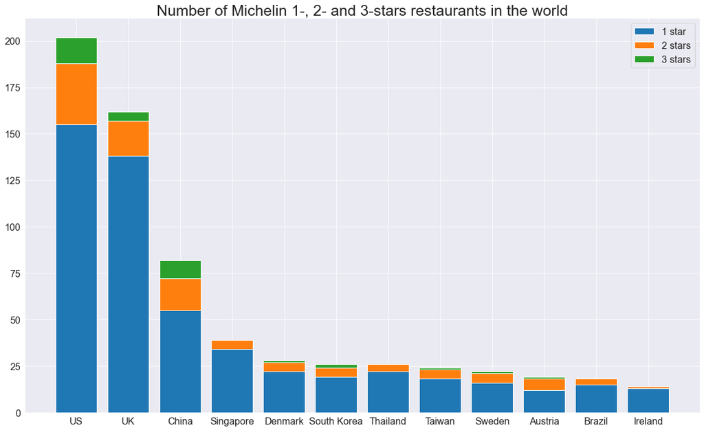

```python
fig, ax = plt.subplots(figsize = (20,12))
ax.set_title('Number of Michelin 1-, 2- and 3-stars restaurants in the world', fontsize = 25)
ax.bar(michelin_countries_stars_df['country'].unique(), michelin_countries_stars_df['number_of_n_star_restaurants'].values[::3])
ax.bar(michelin_countries_stars_df['country'].unique(), michelin_countries_stars_df['number_of_n_star_restaurants'].values[1::3], bottom = michelin_countries_stars_df['number_of_n_star_restaurants'].values[::3])
ax.bar(michelin_countries_stars_df['country'].unique(), michelin_countries_stars_df['number_of_n_star_restaurants'].values[2::3], bottom = michelin_countries_stars_df['number_of_n_star_restaurants'].values[::3] + michelin_countries_stars_df['number_of_n_star_restaurants'].values[1::3])
ax.legend(['1 star', '2 stars', '3 stars'])

plt.show()
```

### Geographic distribution of the restaurants in every continent

```python
michelin_n_america_df = michelin_df[michelin_df['continent'] == 'North America'][['latitude', 'longitude']].reset_index()
michelin_s_america_df = michelin_df[michelin_df['continent'] == 'South America'][['latitude', 'longitude']].reset_index()
michelin_europe_df = michelin_df[michelin_df['continent'] == 'Europe'][['latitude', 'longitude']].reset_index()
michelin_asia_df = michelin_df[michelin_df['continent'] == 'Asia'][['latitude', 'longitude']].reset_index()
```

```python
michelin_n_america_df
```

|  | index | latitude | longitude |
| --- | --- | --- | --- |
| 0 | 12 | 37.394680 | -122.08044 |
| 1 | 13 | 37.427853 | -122.14362 |
| 2 | 14 | 37.420140 | -122.21151 |
| 3 | 15 | 37.428970 | -122.25178 |
| 4 | 16 | 37.256480 | -122.03537 |
| ... | ... | ... | ... |
| 197 | 681 | 40.768280 | -73.98292 |
| 198 | 682 | 40.761770 | -73.98223 |
| 199 | 683 | 40.741700 | -73.98712 |
| 200 | 684 | 40.688720 | -73.98581 |
| 201 | 689 | 38.713623 | -78.16208 |

202 rows × 3 columns

```python
michelin_s_america_df
```

|  | index | latitude | longitude |
| --- | --- | --- | --- |
| 0 | 274 | -22.961090 | -43.206580 |
| 1 | 275 | -22.954010 | -43.195570 |
| 2 | 276 | -22.957470 | -43.194424 |
| 3 | 277 | -22.967640 | -43.179250 |
| 4 | 278 | -22.967550 | -43.179010 |
| 5 | 279 | -23.563180 | -46.677370 |
| 6 | 280 | -23.566210 | -46.679740 |
| 7 | 281 | -23.567078 | -46.679146 |
| 8 | 282 | -23.565063 | -46.666767 |
| 9 | 283 | -23.585220 | -46.680900 |
| 10 | 284 | -23.581320 | -46.676700 |
| 11 | 285 | -23.634005 | -46.724280 |
| 12 | 286 | -23.591590 | -46.671460 |
| 13 | 287 | -23.568400 | -46.649360 |
| 14 | 288 | -23.608820 | -46.659800 |
| 15 | 611 | -22.986010 | -43.224710 |
| 16 | 612 | -23.556530 | -46.690830 |
| 17 | 613 | -23.566180 | -46.667420 |

```python
michelin_europe_df
```

|  | index | latitude | longitude |
| --- | --- | --- | --- |
| 0 | 0 | 47.348580 | 10.171140 |
| 1 | 1 | 47.837870 | 13.079170 |
| 2 | 2 | 47.806850 | 13.034090 |
| 3 | 3 | 47.800010 | 13.040060 |
| 4 | 4 | 48.216503 | 16.368520 |
| ... | ... | ... | ... |
| 273 | 690 | 51.508280 | -0.702320 |
| 274 | 691 | 51.507730 | -0.701210 |
| 275 | 692 | 51.507120 | -0.152520 |
| 276 | 693 | 51.511826 | -0.140389 |
| 277 | 694 | 51.485460 | -0.162020 |

278 rows × 3 columns

```python
michelin_asia_df
```

|  | index | latitude | longitude |
| --- | --- | --- | --- |
| 0 | 137 | 22.379858 | 114.27188 |
| 1 | 138 | 22.312672 | 114.22482 |
| 2 | 139 | 22.328050 | 114.16665 |
| 3 | 140 | 22.320219 | 114.17133 |
| 4 | 141 | 22.318314 | 114.16933 |
| ... | ... | ... | ... |
| 192 | 677 | 22.189949 | 113.54395 |
| 193 | 678 | 22.149137 | 113.56715 |
| 194 | 685 | 37.555813 | 127.00517 |
| 195 | 686 | 37.522650 | 127.03595 |
| 196 | 688 | 25.049496 | 121.51674 |

197 rows × 3 columns

**A good way to prepare pivot tables from above DataFrames is to aggregate data into specific bins**

```python
bins_n_america1 = np.arange(26,50)
bins_n_america2 = np.arange(-125,-65)
michelin_n_america_df['latitude_bins'] = pd.cut(michelin_n_america_df['latitude'], bins_n_america1)
michelin_n_america_df['longitude_bins'] = pd.cut(michelin_n_america_df['longitude'], bins_n_america2)

bins_s_america1 = np.arange(-42,6)
bins_s_america2 = np.arange(-72,-34)
michelin_s_america_df['latitude_bins'] = pd.cut(michelin_s_america_df['latitude'], bins_s_america1)
michelin_s_america_df['longitude_bins'] = pd.cut(michelin_s_america_df['longitude'], bins_s_america2)

bins_europe1 = np.arange(34,70)
bins_europe2 = np.arange(-24,42)
michelin_europe_df['latitude_bins'] = pd.cut(michelin_europe_df['latitude'], bins_europe1)
michelin_europe_df['longitude_bins'] = pd.cut(michelin_europe_df['longitude'], bins_europe2)

bins_asia1 = np.arange(42)
bins_asia2 = np.arange(90,135)
michelin_asia_df['latitude_bins'] = pd.cut(michelin_asia_df['latitude'], bins_asia1)
michelin_asia_df['longitude_bins'] = pd.cut(michelin_asia_df['longitude'], bins_asia2)
```

```python
michelin_n_america_df = michelin_n_america_df.groupby(['latitude_bins', 'longitude_bins'])[['latitude_bins']].count()

michelin_n_america_df.rename(columns = {'latitude_bins': 'number_of_restaurants'}, inplace = True)

michelin_n_america_df
```

| latitude_bins | longitude_bins | number_of_restaurants |
| --- | --- | --- |
| (26, 27] | (-125, -124] | NaN |
|  | (-124, -123] | NaN |
|  | (-123, -122] | NaN |
|  | (-122, -121] | NaN |
|  | (-121, -120] | NaN |
| ... | ... | ... |
| (48, 49] | (-71, -70] | NaN |
|  | (-70, -69] | NaN |
|  | (-69, -68] | NaN |
|  | (-68, -67] | NaN |
|  | (-67, -66] | NaN |

1357 rows × 1 columns

```python
michelin_s_america_df = michelin_s_america_df.groupby(['latitude_bins', 'longitude_bins'])[['latitude_bins']].count()

michelin_s_america_df.rename(columns = {'latitude_bins': 'number_of_restaurants'}, inplace = True)

michelin_s_america_df
```

| latitude_bins | longitude_bins | number_of_restaurants |
| --- | --- | --- |
| (-42, -41] | (-72, -71] | NaN |
|  | (-71, -70] | NaN |
|  | (-70, -69] | NaN |
|  | (-69, -68] | NaN |
|  | (-68, -67] | NaN |
| ... | ... | ... |
| (4, 5] | (-40, -39] | NaN |
|  | (-39, -38] | NaN |
|  | (-38, -37] | NaN |
|  | (-37, -36] | NaN |
|  | (-36, -35] | NaN |

1739 rows × 1 columns

```python
michelin_europe_df = michelin_europe_df.groupby(['latitude_bins', 'longitude_bins'])[['latitude_bins']].count()

michelin_europe_df.rename(columns = {'latitude_bins': 'number_of_restaurants'}, inplace = True)

michelin_europe_df
```

| latitude_bins | longitude_bins | number_of_restaurants |
| --- | --- | --- |
| (34, 35] | (-24, -23] | NaN |
|  | (-23, -22] | NaN |
|  | (-22, -21] | NaN |
|  | (-21, -20] | NaN |
|  | (-20, -19] | NaN |
| ... | ... | ... |
| (68, 69] | (36, 37] | NaN |
|  | (37, 38] | NaN |
|  | (38, 39] | NaN |
|  | (39, 40] | NaN |
|  | (40, 41] | NaN |

2275 rows × 1 columns

```python
michelin_asia_df = michelin_asia_df.groupby(['latitude_bins', 'longitude_bins'])[['latitude_bins']].count()

michelin_asia_df.rename(columns = {'latitude_bins': 'number_of_restaurants'}, inplace = True)

michelin_asia_df
```

| latitude_bins | longitude_bins | number_of_restaurants |
| --- | --- | --- |
| (0, 1] | (90, 91] | NaN |
|  | (91, 92] | NaN |
|  | (92, 93] | NaN |
|  | (93, 94] | NaN |
|  | (94, 95] | NaN |
| ... | ... | ... |
| (40, 41] | (129, 130] | NaN |
|  | (130, 131] | NaN |
|  | (131, 132] | NaN |
|  | (132, 133] | NaN |
|  | (133, 134] | NaN |

1804 rows × 1 columns

```python
michelin_n_america_df = michelin_n_america_df.reset_index(level=[0,1])
michelin_s_america_df = michelin_s_america_df.reset_index(level=[0,1])
michelin_europe_df = michelin_europe_df.reset_index(level=[0,1])
michelin_asia_df = michelin_asia_df.reset_index(level=[0,1])
```

**Below I create the pivot tables and heatmaps that present the distribution of restaurants in given continents and later I superimpose those heatmaps on the maps of the continents.**

```python
michelin_n_america_df_pivot = michelin_n_america_df.pivot('latitude_bins', 'longitude_bins', 'number_of_restaurants')
michelin_n_america_df_pivot.sort_index(ascending = False, inplace = True)

michelin_n_america_df_pivot
```

| longitude_bins latitude_bins | (-125, -124] | (-124, -123] | (-123, -122] | (-122, -121] | (-121, -120] | (-120, -119] | (-119, -118] | (-118, -117] | (-117, -116] | (-116, -115] | ... | (-76, -75] | (-75, -74] | (-74, -73] | (-73, -72] | (-72, -71] | (-71, -70] | (-70, -69] | (-69, -68] | (-68, -67] | (-67, -66] |
| --- | --- | --- | --- | --- | --- | --- | --- | --- | --- | --- | --- | --- | --- | --- | --- | --- | --- | --- | --- | --- | --- |
| (48, 49] | NaN | NaN | NaN | NaN | NaN | NaN | NaN | NaN | NaN | NaN | ... | NaN | NaN | NaN | NaN | NaN | NaN | NaN | NaN | NaN | NaN |
| (47, 48] | NaN | NaN | NaN | NaN | NaN | NaN | NaN | NaN | NaN | NaN | ... | NaN | NaN | NaN | NaN | NaN | NaN | NaN | NaN | NaN | NaN |
| (46, 47] | NaN | NaN | NaN | NaN | NaN | NaN | NaN | NaN | NaN | NaN | ... | NaN | NaN | NaN | NaN | NaN | NaN | NaN | NaN | NaN | NaN |
| (45, 46] | NaN | NaN | NaN | NaN | NaN | NaN | NaN | NaN | NaN | NaN | ... | NaN | NaN | NaN | NaN | NaN | NaN | NaN | NaN | NaN | NaN |
| (44, 45] | NaN | NaN | NaN | NaN | NaN | NaN | NaN | NaN | NaN | NaN | ... | NaN | NaN | NaN | NaN | NaN | NaN | NaN | NaN | NaN | NaN |
| (43, 44] | NaN | NaN | NaN | NaN | NaN | NaN | NaN | NaN | NaN | NaN | ... | NaN | NaN | NaN | NaN | NaN | NaN | NaN | NaN | NaN | NaN |
| (42, 43] | NaN | NaN | NaN | NaN | NaN | NaN | NaN | NaN | NaN | NaN | ... | NaN | NaN | NaN | NaN | NaN | NaN | NaN | NaN | NaN | NaN |
| (41, 42] | NaN | NaN | NaN | NaN | NaN | NaN | NaN | NaN | NaN | NaN | ... | NaN | NaN | NaN | NaN | NaN | NaN | NaN | NaN | NaN | NaN |
| (40, 41] | NaN | NaN | NaN | NaN | NaN | NaN | NaN | NaN | NaN | NaN | ... | NaN | 16.0 | 58.0 | NaN | NaN | NaN | NaN | NaN | NaN | NaN |
| (39, 40] | NaN | 1.0 | NaN | NaN | NaN | NaN | NaN | NaN | NaN | NaN | ... | NaN | NaN | NaN | NaN | NaN | NaN | NaN | NaN | NaN | NaN |
| (38, 39] | NaN | NaN | 9.0 | 1.0 | NaN | NaN | NaN | NaN | NaN | NaN | ... | NaN | NaN | NaN | NaN | NaN | NaN | NaN | NaN | NaN | NaN |
| (37, 38] | NaN | NaN | 50.0 | 1.0 | NaN | NaN | NaN | NaN | NaN | NaN | ... | NaN | NaN | NaN | NaN | NaN | NaN | NaN | NaN | NaN | NaN |
| (36, 37] | NaN | NaN | NaN | 1.0 | NaN | NaN | NaN | NaN | NaN | NaN | ... | NaN | NaN | NaN | NaN | NaN | NaN | NaN | NaN | NaN | NaN |
| (35, 36] | NaN | NaN | NaN | NaN | NaN | NaN | NaN | NaN | NaN | NaN | ... | NaN | NaN | NaN | NaN | NaN | NaN | NaN | NaN | NaN | NaN |
| (34, 35] | NaN | NaN | NaN | NaN | NaN | NaN | 23.0 | NaN | NaN | NaN | ... | NaN | NaN | NaN | NaN | NaN | NaN | NaN | NaN | NaN | NaN |
| (33, 34] | NaN | NaN | NaN | NaN | NaN | NaN | 1.0 | 2.0 | NaN | NaN | ... | NaN | NaN | NaN | NaN | NaN | NaN | NaN | NaN | NaN | NaN |
| (32, 33] | NaN | NaN | NaN | NaN | NaN | NaN | NaN | 1.0 | NaN | NaN | ... | NaN | NaN | NaN | NaN | NaN | NaN | NaN | NaN | NaN | NaN |
| (31, 32] | NaN | NaN | NaN | NaN | NaN | NaN | NaN | NaN | NaN | NaN | ... | NaN | NaN | NaN | NaN | NaN | NaN | NaN | NaN | NaN | NaN |
| (30, 31] | NaN | NaN | NaN | NaN | NaN | NaN | NaN | NaN | NaN | NaN | ... | NaN | NaN | NaN | NaN | NaN | NaN | NaN | NaN | NaN | NaN |
| (29, 30] | NaN | NaN | NaN | NaN | NaN | NaN | NaN | NaN | NaN | NaN | ... | NaN | NaN | NaN | NaN | NaN | NaN | NaN | NaN | NaN | NaN |
| (28, 29] | NaN | NaN | NaN | NaN | NaN | NaN | NaN | NaN | NaN | NaN | ... | NaN | NaN | NaN | NaN | NaN | NaN | NaN | NaN | NaN | NaN |
| (27, 28] | NaN | NaN | NaN | NaN | NaN | NaN | NaN | NaN | NaN | NaN | ... | NaN | NaN | NaN | NaN | NaN | NaN | NaN | NaN | NaN | NaN |
| (26, 27] | NaN | NaN | NaN | NaN | NaN | NaN | NaN | NaN | NaN | NaN | ... | NaN | NaN | NaN | NaN | NaN | NaN | NaN | NaN | NaN | NaN |

23 rows × 59 columns

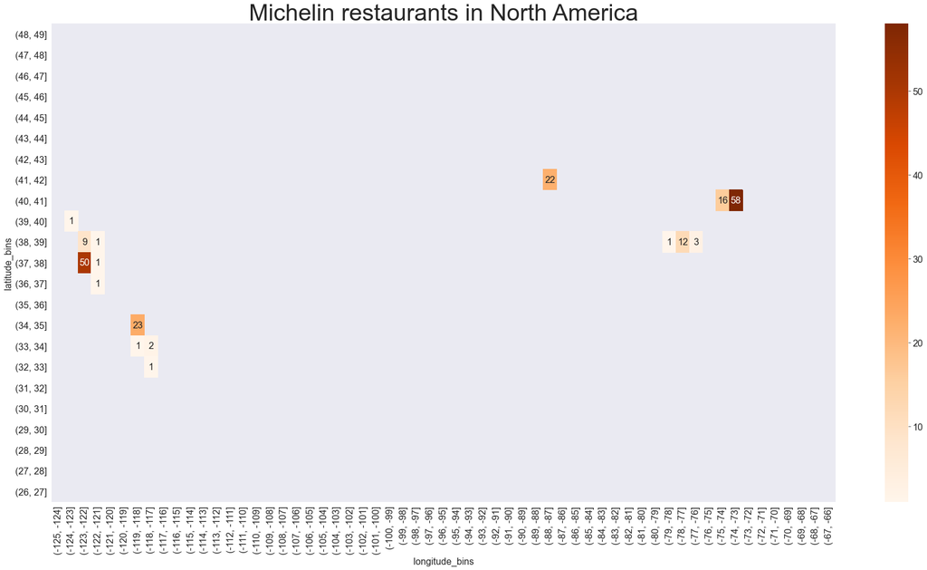

```python
fig, ax = plt.subplots(figsize = (30,15))
ax.set_title('Michelin restaurants in North America', fontsize = 40)
ax = sns.heatmap(michelin_n_america_df_pivot, annot = True, cmap = 'Oranges')

fig.savefig(r'C:\Users\ASUS\Desktop\Programming\Python\Michelin_project\heatmap_n_america', transparent = True)
```

```python
from PIL import Image
```

[figure not shown]

```python
n_america_map = Image.open(r'C:\Users\ASUS\Desktop\Programming\Python\Michelin_project\n_america_map.png')

plt.figure(figsize = (25,15))
plt.axis('off')
plt.title('Michelin restaurants in North America', fontsize = 40)
plt.imshow(n_america_map);
```

```python
michelin_s_america_df_pivot = michelin_s_america_df.pivot('latitude_bins', 'longitude_bins', 'number_of_restaurants')
michelin_s_america_df_pivot.sort_index(ascending = False, inplace = True)

michelin_s_america_df_pivot
```

| longitude_bins latitude_bins | (-72, -71] | (-71, -70] | (-70, -69] | (-69, -68] | (-68, -67] | (-67, -66] | (-66, -65] | (-65, -64] | (-64, -63] | (-63, -62] | ... | (-45, -44] | (-44, -43] | (-43, -42] | (-42, -41] | (-41, -40] | (-40, -39] | (-39, -38] | (-38, -37] | (-37, -36] | (-36, -35] |
| --- | --- | --- | --- | --- | --- | --- | --- | --- | --- | --- | --- | --- | --- | --- | --- | --- | --- | --- | --- | --- | --- |
| (4, 5] | NaN | NaN | NaN | NaN | NaN | NaN | NaN | NaN | NaN | NaN | ... | NaN | NaN | NaN | NaN | NaN | NaN | NaN | NaN | NaN | NaN |
| (3, 4] | NaN | NaN | NaN | NaN | NaN | NaN | NaN | NaN | NaN | NaN | ... | NaN | NaN | NaN | NaN | NaN | NaN | NaN | NaN | NaN | NaN |
| (2, 3] | NaN | NaN | NaN | NaN | NaN | NaN | NaN | NaN | NaN | NaN | ... | NaN | NaN | NaN | NaN | NaN | NaN | NaN | NaN | NaN | NaN |
| (1, 2] | NaN | NaN | NaN | NaN | NaN | NaN | NaN | NaN | NaN | NaN | ... | NaN | NaN | NaN | NaN | NaN | NaN | NaN | NaN | NaN | NaN |
| (0, 1] | NaN | NaN | NaN | NaN | NaN | NaN | NaN | NaN | NaN | NaN | ... | NaN | NaN | NaN | NaN | NaN | NaN | NaN | NaN | NaN | NaN |
| (-1, 0] | NaN | NaN | NaN | NaN | NaN | NaN | NaN | NaN | NaN | NaN | ... | NaN | NaN | NaN | NaN | NaN | NaN | NaN | NaN | NaN | NaN |
| (-2, -1] | NaN | NaN | NaN | NaN | NaN | NaN | NaN | NaN | NaN | NaN | ... | NaN | NaN | NaN | NaN | NaN | NaN | NaN | NaN | NaN | NaN |
| (-3, -2] | NaN | NaN | NaN | NaN | NaN | NaN | NaN | NaN | NaN | NaN | ... | NaN | NaN | NaN | NaN | NaN | NaN | NaN | NaN | NaN | NaN |
| (-4, -3] | NaN | NaN | NaN | NaN | NaN | NaN | NaN | NaN | NaN | NaN | ... | NaN | NaN | NaN | NaN | NaN | NaN | NaN | NaN | NaN | NaN |
| (-5, -4] | NaN | NaN | NaN | NaN | NaN | NaN | NaN | NaN | NaN | NaN | ... | NaN | NaN | NaN | NaN | NaN | NaN | NaN | NaN | NaN | NaN |
| (-6, -5] | NaN | NaN | NaN | NaN | NaN | NaN | NaN | NaN | NaN | NaN | ... | NaN | NaN | NaN | NaN | NaN | NaN | NaN | NaN | NaN | NaN |
| (-7, -6] | NaN | NaN | NaN | NaN | NaN | NaN | NaN | NaN | NaN | NaN | ... | NaN | NaN | NaN | NaN | NaN | NaN | NaN | NaN | NaN | NaN |
| (-8, -7] | NaN | NaN | NaN | NaN | NaN | NaN | NaN | NaN | NaN | NaN | ... | NaN | NaN | NaN | NaN | NaN | NaN | NaN | NaN | NaN | NaN |
| (-9, -8] | NaN | NaN | NaN | NaN | NaN | NaN | NaN | NaN | NaN | NaN | ... | NaN | NaN | NaN | NaN | NaN | NaN | NaN | NaN | NaN | NaN |
| (-10, -9] | NaN | NaN | NaN | NaN | NaN | NaN | NaN | NaN | NaN | NaN | ... | NaN | NaN | NaN | NaN | NaN | NaN | NaN | NaN | NaN | NaN |
| (-11, -10] | NaN | NaN | NaN | NaN | NaN | NaN | NaN | NaN | NaN | NaN | ... | NaN | NaN | NaN | NaN | NaN | NaN | NaN | NaN | NaN | NaN |
| (-12, -11] | NaN | NaN | NaN | NaN | NaN | NaN | NaN | NaN | NaN | NaN | ... | NaN | NaN | NaN | NaN | NaN | NaN | NaN | NaN | NaN | NaN |
| (-13, -12] | NaN | NaN | NaN | NaN | NaN | NaN | NaN | NaN | NaN | NaN | ... | NaN | NaN | NaN | NaN | NaN | NaN | NaN | NaN | NaN | NaN |
| (-14, -13] | NaN | NaN | NaN | NaN | NaN | NaN | NaN | NaN | NaN | NaN | ... | NaN | NaN | NaN | NaN | NaN | NaN | NaN | NaN | NaN | NaN |
| (-15, -14] | NaN | NaN | NaN | NaN | NaN | NaN | NaN | NaN | NaN | NaN | ... | NaN | NaN | NaN | NaN | NaN | NaN | NaN | NaN | NaN | NaN |
| (-16, -15] | NaN | NaN | NaN | NaN | NaN | NaN | NaN | NaN | NaN | NaN | ... | NaN | NaN | NaN | NaN | NaN | NaN | NaN | NaN | NaN | NaN |
| (-17, -16] | NaN | NaN | NaN | NaN | NaN | NaN | NaN | NaN | NaN | NaN | ... | NaN | NaN | NaN | NaN | NaN | NaN | NaN | NaN | NaN | NaN |
| (-18, -17] | NaN | NaN | NaN | NaN | NaN | NaN | NaN | NaN | NaN | NaN | ... | NaN | NaN | NaN | NaN | NaN | NaN | NaN | NaN | NaN | NaN |
| (-19, -18] | NaN | NaN | NaN | NaN | NaN | NaN | NaN | NaN | NaN | NaN | ... | NaN | NaN | NaN | NaN | NaN | NaN | NaN | NaN | NaN | NaN |
| (-20, -19] | NaN | NaN | NaN | NaN | NaN | NaN | NaN | NaN | NaN | NaN | ... | NaN | NaN | NaN | NaN | NaN | NaN | NaN | NaN | NaN | NaN |
| (-21, -20] | NaN | NaN | NaN | NaN | NaN | NaN | NaN | NaN | NaN | NaN | ... | NaN | NaN | NaN | NaN | NaN | NaN | NaN | NaN | NaN | NaN |
| (-22, -21] | NaN | NaN | NaN | NaN | NaN | NaN | NaN | NaN | NaN | NaN | ... | NaN | NaN | NaN | NaN | NaN | NaN | NaN | NaN | NaN | NaN |
| (-23, -22] | NaN | NaN | NaN | NaN | NaN | NaN | NaN | NaN | NaN | NaN | ... | NaN | 6.0 | NaN | NaN | NaN | NaN | NaN | NaN | NaN | NaN |
| (-24, -23] | NaN | NaN | NaN | NaN | NaN | NaN | NaN | NaN | NaN | NaN | ... | NaN | NaN | NaN | NaN | NaN | NaN | NaN | NaN | NaN | NaN |
| (-25, -24] | NaN | NaN | NaN | NaN | NaN | NaN | NaN | NaN | NaN | NaN | ... | NaN | NaN | NaN | NaN | NaN | NaN | NaN | NaN | NaN | NaN |
| (-26, -25] | NaN | NaN | NaN | NaN | NaN | NaN | NaN | NaN | NaN | NaN | ... | NaN | NaN | NaN | NaN | NaN | NaN | NaN | NaN | NaN | NaN |
| (-27, -26] | NaN | NaN | NaN | NaN | NaN | NaN | NaN | NaN | NaN | NaN | ... | NaN | NaN | NaN | NaN | NaN | NaN | NaN | NaN | NaN | NaN |
| (-28, -27] | NaN | NaN | NaN | NaN | NaN | NaN | NaN | NaN | NaN | NaN | ... | NaN | NaN | NaN | NaN | NaN | NaN | NaN | NaN | NaN | NaN |
| (-29, -28] | NaN | NaN | NaN | NaN | NaN | NaN | NaN | NaN | NaN | NaN | ... | NaN | NaN | NaN | NaN | NaN | NaN | NaN | NaN | NaN | NaN |
| (-30, -29] | NaN | NaN | NaN | NaN | NaN | NaN | NaN | NaN | NaN | NaN | ... | NaN | NaN | NaN | NaN | NaN | NaN | NaN | NaN | NaN | NaN |
| (-31, -30] | NaN | NaN | NaN | NaN | NaN | NaN | NaN | NaN | NaN | NaN | ... | NaN | NaN | NaN | NaN | NaN | NaN | NaN | NaN | NaN | NaN |
| (-32, -31] | NaN | NaN | NaN | NaN | NaN | NaN | NaN | NaN | NaN | NaN | ... | NaN | NaN | NaN | NaN | NaN | NaN | NaN | NaN | NaN | NaN |
| (-33, -32] | NaN | NaN | NaN | NaN | NaN | NaN | NaN | NaN | NaN | NaN | ... | NaN | NaN | NaN | NaN | NaN | NaN | NaN | NaN | NaN | NaN |
| (-34, -33] | NaN | NaN | NaN | NaN | NaN | NaN | NaN | NaN | NaN | NaN | ... | NaN | NaN | NaN | NaN | NaN | NaN | NaN | NaN | NaN | NaN |
| (-35, -34] | NaN | NaN | NaN | NaN | NaN | NaN | NaN | NaN | NaN | NaN | ... | NaN | NaN | NaN | NaN | NaN | NaN | NaN | NaN | NaN | NaN |
| (-36, -35] | NaN | NaN | NaN | NaN | NaN | NaN | NaN | NaN | NaN | NaN | ... | NaN | NaN | NaN | NaN | NaN | NaN | NaN | NaN | NaN | NaN |
| (-37, -36] | NaN | NaN | NaN | NaN | NaN | NaN | NaN | NaN | NaN | NaN | ... | NaN | NaN | NaN | NaN | NaN | NaN | NaN | NaN | NaN | NaN |
| (-38, -37] | NaN | NaN | NaN | NaN | NaN | NaN | NaN | NaN | NaN | NaN | ... | NaN | NaN | NaN | NaN | NaN | NaN | NaN | NaN | NaN | NaN |
| (-39, -38] | NaN | NaN | NaN | NaN | NaN | NaN | NaN | NaN | NaN | NaN | ... | NaN | NaN | NaN | NaN | NaN | NaN | NaN | NaN | NaN | NaN |
| (-40, -39] | NaN | NaN | NaN | NaN | NaN | NaN | NaN | NaN | NaN | NaN | ... | NaN | NaN | NaN | NaN | NaN | NaN | NaN | NaN | NaN | NaN |
| (-41, -40] | NaN | NaN | NaN | NaN | NaN | NaN | NaN | NaN | NaN | NaN | ... | NaN | NaN | NaN | NaN | NaN | NaN | NaN | NaN | NaN | NaN |
| (-42, -41] | NaN | NaN | NaN | NaN | NaN | NaN | NaN | NaN | NaN | NaN | ... | NaN | NaN | NaN | NaN | NaN | NaN | NaN | NaN | NaN | NaN |

47 rows × 37 columns

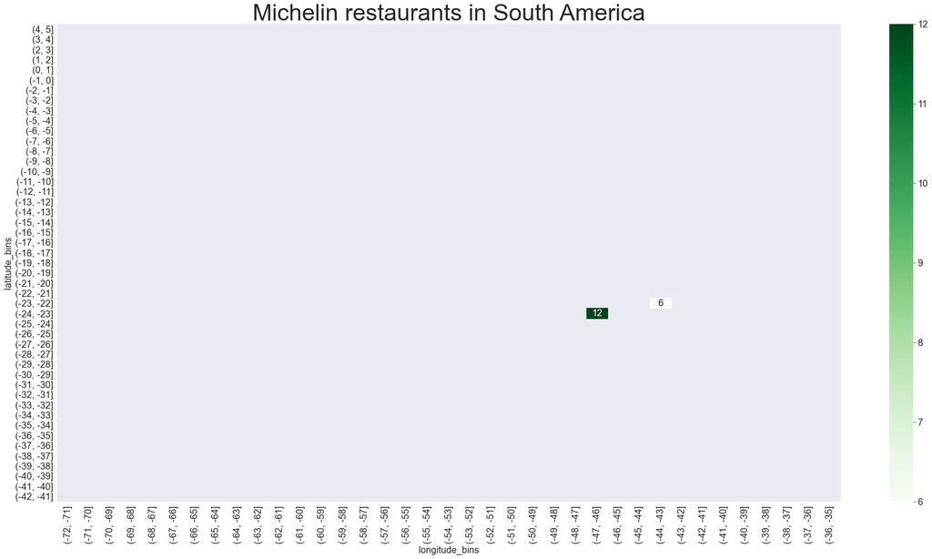

```python
fig, ax = plt.subplots(figsize = (30,15))
ax.set_title('Michelin restaurants in South America', fontsize = 40)
ax = sns.heatmap(michelin_s_america_df_pivot, annot = True, cmap = 'Greens')
fig.savefig(r'C:\Users\ASUS\Desktop\Programming\Python\Michelin_project\heatmap_s_america', transparent = True)
```

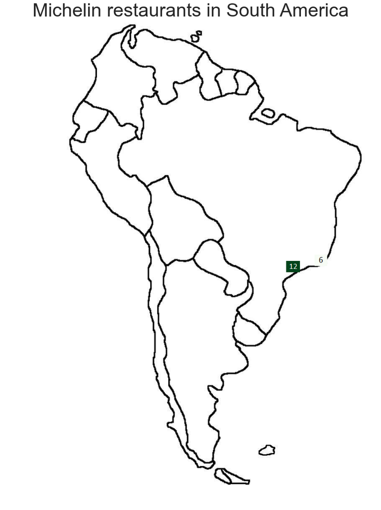

```python
s_america_map = Image.open(r'C:\Users\ASUS\Desktop\Programming\Python\Michelin_project\s_america_map.png')

plt.figure(figsize = (15,19))
plt.axis('off')
plt.title('Michelin restaurants in South America', fontsize = 40)
plt.imshow(s_america_map);
```

```python
michelin_europe_df_pivot = michelin_europe_df.pivot('latitude_bins', 'longitude_bins', 'number_of_restaurants')
michelin_europe_df_pivot.sort_index(ascending = False, inplace = True)

michelin_europe_df_pivot
```

| longitude_bins latitude_bins | (-24, -23] | (-23, -22] | (-22, -21] | (-21, -20] | (-20, -19] | (-19, -18] | (-18, -17] | (-17, -16] | (-16, -15] | (-15, -14] | ... | (31, 32] | (32, 33] | (33, 34] | (34, 35] | (35, 36] | (36, 37] | (37, 38] | (38, 39] | (39, 40] | (40, 41] |
| --- | --- | --- | --- | --- | --- | --- | --- | --- | --- | --- | --- | --- | --- | --- | --- | --- | --- | --- | --- | --- | --- |
| (68, 69] | NaN | NaN | NaN | NaN | NaN | NaN | NaN | NaN | NaN | NaN | ... | NaN | NaN | NaN | NaN | NaN | NaN | NaN | NaN | NaN | NaN |
| (67, 68] | NaN | NaN | NaN | NaN | NaN | NaN | NaN | NaN | NaN | NaN | ... | NaN | NaN | NaN | NaN | NaN | NaN | NaN | NaN | NaN | NaN |
| (66, 67] | NaN | NaN | NaN | NaN | NaN | NaN | NaN | NaN | NaN | NaN | ... | NaN | NaN | NaN | NaN | NaN | NaN | NaN | NaN | NaN | NaN |
| (65, 66] | NaN | NaN | NaN | NaN | NaN | NaN | NaN | NaN | NaN | NaN | ... | NaN | NaN | NaN | NaN | NaN | NaN | NaN | NaN | NaN | NaN |
| (64, 65] | NaN | NaN | NaN | NaN | NaN | NaN | NaN | NaN | NaN | NaN | ... | NaN | NaN | NaN | NaN | NaN | NaN | NaN | NaN | NaN | NaN |
| (63, 64] | NaN | NaN | NaN | NaN | NaN | NaN | NaN | NaN | NaN | NaN | ... | NaN | NaN | NaN | NaN | NaN | NaN | NaN | NaN | NaN | NaN |
| (62, 63] | NaN | NaN | NaN | NaN | NaN | NaN | NaN | NaN | NaN | NaN | ... | NaN | NaN | NaN | NaN | NaN | NaN | NaN | NaN | NaN | NaN |
| (61, 62] | NaN | NaN | NaN | NaN | NaN | NaN | NaN | NaN | NaN | NaN | ... | NaN | NaN | NaN | NaN | NaN | NaN | NaN | NaN | NaN | NaN |
| (60, 61] | NaN | NaN | NaN | NaN | NaN | NaN | NaN | NaN | NaN | NaN | ... | NaN | NaN | NaN | NaN | NaN | NaN | NaN | NaN | NaN | NaN |
| (59, 60] | NaN | NaN | NaN | NaN | NaN | NaN | NaN | NaN | NaN | NaN | ... | NaN | NaN | NaN | NaN | NaN | NaN | NaN | NaN | NaN | NaN |
| (58, 59] | NaN | NaN | NaN | NaN | NaN | NaN | NaN | NaN | NaN | NaN | ... | NaN | NaN | NaN | NaN | NaN | NaN | NaN | NaN | NaN | NaN |
| (57, 58] | NaN | NaN | NaN | NaN | NaN | NaN | NaN | NaN | NaN | NaN | ... | NaN | NaN | NaN | NaN | NaN | NaN | NaN | NaN | NaN | NaN |
| (56, 57] | NaN | NaN | NaN | NaN | NaN | NaN | NaN | NaN | NaN | NaN | ... | NaN | NaN | NaN | NaN | NaN | NaN | NaN | NaN | NaN | NaN |
| (55, 56] | NaN | NaN | NaN | NaN | NaN | NaN | NaN | NaN | NaN | NaN | ... | NaN | NaN | NaN | NaN | NaN | NaN | NaN | NaN | NaN | NaN |
| (54, 55] | NaN | NaN | NaN | NaN | NaN | NaN | NaN | NaN | NaN | NaN | ... | NaN | NaN | NaN | NaN | NaN | NaN | NaN | NaN | NaN | NaN |
| (53, 54] | NaN | NaN | NaN | NaN | NaN | NaN | NaN | NaN | NaN | NaN | ... | NaN | NaN | NaN | NaN | NaN | NaN | NaN | NaN | NaN | NaN |
| (52, 53] | NaN | NaN | NaN | NaN | NaN | NaN | NaN | NaN | NaN | NaN | ... | NaN | NaN | NaN | NaN | NaN | NaN | NaN | NaN | NaN | NaN |
| (51, 52] | NaN | NaN | NaN | NaN | NaN | NaN | NaN | NaN | NaN | NaN | ... | NaN | NaN | NaN | NaN | NaN | NaN | NaN | NaN | NaN | NaN |
| (50, 51] | NaN | NaN | NaN | NaN | NaN | NaN | NaN | NaN | NaN | NaN | ... | NaN | NaN | NaN | NaN | NaN | NaN | NaN | NaN | NaN | NaN |
| (49, 50] | NaN | NaN | NaN | NaN | NaN | NaN | NaN | NaN | NaN | NaN | ... | NaN | NaN | NaN | NaN | NaN | NaN | NaN | NaN | NaN | NaN |
| (48, 49] | NaN | NaN | NaN | NaN | NaN | NaN | NaN | NaN | NaN | NaN | ... | NaN | NaN | NaN | NaN | NaN | NaN | NaN | NaN | NaN | NaN |
| (47, 48] | NaN | NaN | NaN | NaN | NaN | NaN | NaN | NaN | NaN | NaN | ... | NaN | NaN | NaN | NaN | NaN | NaN | NaN | NaN | NaN | NaN |
| (46, 47] | NaN | NaN | NaN | NaN | NaN | NaN | NaN | NaN | NaN | NaN | ... | NaN | NaN | NaN | NaN | NaN | NaN | NaN | NaN | NaN | NaN |
| (45, 46] | NaN | NaN | NaN | NaN | NaN | NaN | NaN | NaN | NaN | NaN | ... | NaN | NaN | NaN | NaN | NaN | NaN | NaN | NaN | NaN | NaN |
| (44, 45] | NaN | NaN | NaN | NaN | NaN | NaN | NaN | NaN | NaN | NaN | ... | NaN | NaN | NaN | NaN | NaN | NaN | NaN | NaN | NaN | NaN |
| (43, 44] | NaN | NaN | NaN | NaN | NaN | NaN | NaN | NaN | NaN | NaN | ... | NaN | NaN | NaN | NaN | NaN | NaN | NaN | NaN | NaN | NaN |
| (42, 43] | NaN | NaN | NaN | NaN | NaN | NaN | NaN | NaN | NaN | NaN | ... | NaN | NaN | NaN | NaN | NaN | NaN | NaN | NaN | NaN | NaN |
| (41, 42] | NaN | NaN | NaN | NaN | NaN | NaN | NaN | NaN | NaN | NaN | ... | NaN | NaN | NaN | NaN | NaN | NaN | NaN | NaN | NaN | NaN |
| (40, 41] | NaN | NaN | NaN | NaN | NaN | NaN | NaN | NaN | NaN | NaN | ... | NaN | NaN | NaN | NaN | NaN | NaN | NaN | NaN | NaN | NaN |
| (39, 40] | NaN | NaN | NaN | NaN | NaN | NaN | NaN | NaN | NaN | NaN | ... | NaN | NaN | NaN | NaN | NaN | NaN | NaN | NaN | NaN | NaN |
| (38, 39] | NaN | NaN | NaN | NaN | NaN | NaN | NaN | NaN | NaN | NaN | ... | NaN | NaN | NaN | NaN | NaN | NaN | NaN | NaN | NaN | NaN |
| (37, 38] | NaN | NaN | NaN | NaN | NaN | NaN | NaN | NaN | NaN | NaN | ... | NaN | NaN | NaN | NaN | NaN | NaN | NaN | NaN | NaN | NaN |
| (36, 37] | NaN | NaN | NaN | NaN | NaN | NaN | NaN | NaN | NaN | NaN | ... | NaN | NaN | NaN | NaN | NaN | NaN | NaN | NaN | NaN | NaN |
| (35, 36] | NaN | NaN | NaN | NaN | NaN | NaN | NaN | NaN | NaN | NaN | ... | NaN | NaN | NaN | NaN | NaN | NaN | NaN | NaN | NaN | NaN |
| (34, 35] | NaN | NaN | NaN | NaN | NaN | NaN | NaN | NaN | NaN | NaN | ... | NaN | NaN | NaN | NaN | NaN | NaN | NaN | NaN | NaN | NaN |

35 rows × 65 columns

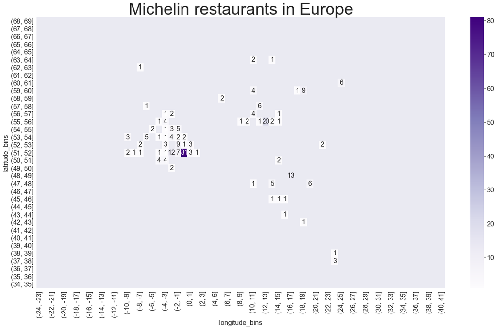

```python
fig, ax = plt.subplots(figsize = (22,12))
ax.set_title('Michelin restaurants in Europe', fontsize = 40)
ax = sns.heatmap(michelin_europe_df_pivot, annot = True, cmap = 'Purples')
fig.savefig(r'C:\Users\ASUS\Desktop\Programming\Python\Michelin_project\heatmap_europe', transparent = True)
```

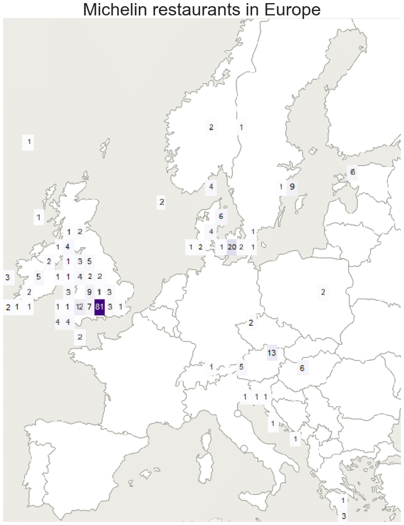

```python
europe_map = Image.open(r'C:\Users\ASUS\Desktop\Programming\Python\Michelin_project\europe_map.png')

plt.figure(figsize = (17,21))
plt.axis('off')
plt.title('Michelin restaurants in Europe', fontsize = 40)
plt.imshow(europe_map);
```

```python
michelin_asia_df_pivot = michelin_asia_df.pivot('latitude_bins', 'longitude_bins', 'number_of_restaurants')
michelin_asia_df_pivot.sort_index(ascending = False, inplace = True)

michelin_asia_df_pivot
```

| longitude_bins latitude_bins | (90, 91] | (91, 92] | (92, 93] | (93, 94] | (94, 95] | (95, 96] | (96, 97] | (97, 98] | (98, 99] | (99, 100] | ... | (124, 125] | (125, 126] | (126, 127] | (127, 128] | (128, 129] | (129, 130] | (130, 131] | (131, 132] | (132, 133] | (133, 134] |
| --- | --- | --- | --- | --- | --- | --- | --- | --- | --- | --- | --- | --- | --- | --- | --- | --- | --- | --- | --- | --- | --- |
| (40, 41] | NaN | NaN | NaN | NaN | NaN | NaN | NaN | NaN | NaN | NaN | ... | NaN | NaN | NaN | NaN | NaN | NaN | NaN | NaN | NaN | NaN |
| (39, 40] | NaN | NaN | NaN | NaN | NaN | NaN | NaN | NaN | NaN | NaN | ... | NaN | NaN | NaN | NaN | NaN | NaN | NaN | NaN | NaN | NaN |
| (38, 39] | NaN | NaN | NaN | NaN | NaN | NaN | NaN | NaN | NaN | NaN | ... | NaN | NaN | NaN | NaN | NaN | NaN | NaN | NaN | NaN | NaN |
| (37, 38] | NaN | NaN | NaN | NaN | NaN | NaN | NaN | NaN | NaN | NaN | ... | NaN | NaN | 11.0 | 15.0 | NaN | NaN | NaN | NaN | NaN | NaN |
| (36, 37] | NaN | NaN | NaN | NaN | NaN | NaN | NaN | NaN | NaN | NaN | ... | NaN | NaN | NaN | NaN | NaN | NaN | NaN | NaN | NaN | NaN |
| (35, 36] | NaN | NaN | NaN | NaN | NaN | NaN | NaN | NaN | NaN | NaN | ... | NaN | NaN | NaN | NaN | NaN | NaN | NaN | NaN | NaN | NaN |
| (34, 35] | NaN | NaN | NaN | NaN | NaN | NaN | NaN | NaN | NaN | NaN | ... | NaN | NaN | NaN | NaN | NaN | NaN | NaN | NaN | NaN | NaN |
| (33, 34] | NaN | NaN | NaN | NaN | NaN | NaN | NaN | NaN | NaN | NaN | ... | NaN | NaN | NaN | NaN | NaN | NaN | NaN | NaN | NaN | NaN |
| (32, 33] | NaN | NaN | NaN | NaN | NaN | NaN | NaN | NaN | NaN | NaN | ... | NaN | NaN | NaN | NaN | NaN | NaN | NaN | NaN | NaN | NaN |
| (31, 32] | NaN | NaN | NaN | NaN | NaN | NaN | NaN | NaN | NaN | NaN | ... | NaN | NaN | NaN | NaN | NaN | NaN | NaN | NaN | NaN | NaN |
| (30, 31] | NaN | NaN | NaN | NaN | NaN | NaN | NaN | NaN | NaN | NaN | ... | NaN | NaN | NaN | NaN | NaN | NaN | NaN | NaN | NaN | NaN |
| (29, 30] | NaN | NaN | NaN | NaN | NaN | NaN | NaN | NaN | NaN | NaN | ... | NaN | NaN | NaN | NaN | NaN | NaN | NaN | NaN | NaN | NaN |
| (28, 29] | NaN | NaN | NaN | NaN | NaN | NaN | NaN | NaN | NaN | NaN | ... | NaN | NaN | NaN | NaN | NaN | NaN | NaN | NaN | NaN | NaN |
| (27, 28] | NaN | NaN | NaN | NaN | NaN | NaN | NaN | NaN | NaN | NaN | ... | NaN | NaN | NaN | NaN | NaN | NaN | NaN | NaN | NaN | NaN |
| (26, 27] | NaN | NaN | NaN | NaN | NaN | NaN | NaN | NaN | NaN | NaN | ... | NaN | NaN | NaN | NaN | NaN | NaN | NaN | NaN | NaN | NaN |
| (25, 26] | NaN | NaN | NaN | NaN | NaN | NaN | NaN | NaN | NaN | NaN | ... | NaN | NaN | NaN | NaN | NaN | NaN | NaN | NaN | NaN | NaN |
| (24, 25] | NaN | NaN | NaN | NaN | NaN | NaN | NaN | NaN | NaN | NaN | ... | NaN | NaN | NaN | NaN | NaN | NaN | NaN | NaN | NaN | NaN |
| (23, 24] | NaN | NaN | NaN | NaN | NaN | NaN | NaN | NaN | NaN | NaN | ... | NaN | NaN | NaN | NaN | NaN | NaN | NaN | NaN | NaN | NaN |
| (22, 23] | NaN | NaN | NaN | NaN | NaN | NaN | NaN | NaN | NaN | NaN | ... | NaN | NaN | NaN | NaN | NaN | NaN | NaN | NaN | NaN | NaN |
| (21, 22] | NaN | NaN | NaN | NaN | NaN | NaN | NaN | NaN | NaN | NaN | ... | NaN | NaN | NaN | NaN | NaN | NaN | NaN | NaN | NaN | NaN |
| (20, 21] | NaN | NaN | NaN | NaN | NaN | NaN | NaN | NaN | NaN | NaN | ... | NaN | NaN | NaN | NaN | NaN | NaN | NaN | NaN | NaN | NaN |
| (19, 20] | NaN | NaN | NaN | NaN | NaN | NaN | NaN | NaN | NaN | NaN | ... | NaN | NaN | NaN | NaN | NaN | NaN | NaN | NaN | NaN | NaN |
| (18, 19] | NaN | NaN | NaN | NaN | NaN | NaN | NaN | NaN | NaN | NaN | ... | NaN | NaN | NaN | NaN | NaN | NaN | NaN | NaN | NaN | NaN |
| (17, 18] | NaN | NaN | NaN | NaN | NaN | NaN | NaN | NaN | NaN | NaN | ... | NaN | NaN | NaN | NaN | NaN | NaN | NaN | NaN | NaN | NaN |
| (16, 17] | NaN | NaN | NaN | NaN | NaN | NaN | NaN | NaN | NaN | NaN | ... | NaN | NaN | NaN | NaN | NaN | NaN | NaN | NaN | NaN | NaN |
| (15, 16] | NaN | NaN | NaN | NaN | NaN | NaN | NaN | NaN | NaN | NaN | ... | NaN | NaN | NaN | NaN | NaN | NaN | NaN | NaN | NaN | NaN |
| (14, 15] | NaN | NaN | NaN | NaN | NaN | NaN | NaN | NaN | NaN | NaN | ... | NaN | NaN | NaN | NaN | NaN | NaN | NaN | NaN | NaN | NaN |
| (13, 14] | NaN | NaN | NaN | NaN | NaN | NaN | NaN | NaN | NaN | NaN | ... | NaN | NaN | NaN | NaN | NaN | NaN | NaN | NaN | NaN | NaN |
| (12, 13] | NaN | NaN | NaN | NaN | NaN | NaN | NaN | NaN | NaN | NaN | ... | NaN | NaN | NaN | NaN | NaN | NaN | NaN | NaN | NaN | NaN |
| (11, 12] | NaN | NaN | NaN | NaN | NaN | NaN | NaN | NaN | NaN | NaN | ... | NaN | NaN | NaN | NaN | NaN | NaN | NaN | NaN | NaN | NaN |
| (10, 11] | NaN | NaN | NaN | NaN | NaN | NaN | NaN | NaN | NaN | NaN | ... | NaN | NaN | NaN | NaN | NaN | NaN | NaN | NaN | NaN | NaN |
| (9, 10] | NaN | NaN | NaN | NaN | NaN | NaN | NaN | NaN | NaN | NaN | ... | NaN | NaN | NaN | NaN | NaN | NaN | NaN | NaN | NaN | NaN |
| (8, 9] | NaN | NaN | NaN | NaN | NaN | NaN | NaN | NaN | 1.0 | NaN | ... | NaN | NaN | NaN | NaN | NaN | NaN | NaN | NaN | NaN | NaN |
| (7, 8] | NaN | NaN | NaN | NaN | NaN | NaN | NaN | NaN | NaN | NaN | ... | NaN | NaN | NaN | NaN | NaN | NaN | NaN | NaN | NaN | NaN |
| (6, 7] | NaN | NaN | NaN | NaN | NaN | NaN | NaN | NaN | NaN | NaN | ... | NaN | NaN | NaN | NaN | NaN | NaN | NaN | NaN | NaN | NaN |
| (5, 6] | NaN | NaN | NaN | NaN | NaN | NaN | NaN | NaN | NaN | NaN | ... | NaN | NaN | NaN | NaN | NaN | NaN | NaN | NaN | NaN | NaN |
| (4, 5] | NaN | NaN | NaN | NaN | NaN | NaN | NaN | NaN | NaN | NaN | ... | NaN | NaN | NaN | NaN | NaN | NaN | NaN | NaN | NaN | NaN |
| (3, 4] | NaN | NaN | NaN | NaN | NaN | NaN | NaN | NaN | NaN | NaN | ... | NaN | NaN | NaN | NaN | NaN | NaN | NaN | NaN | NaN | NaN |
| (2, 3] | NaN | NaN | NaN | NaN | NaN | NaN | NaN | NaN | NaN | NaN | ... | NaN | NaN | NaN | NaN | NaN | NaN | NaN | NaN | NaN | NaN |
| (1, 2] | NaN | NaN | NaN | NaN | NaN | NaN | NaN | NaN | NaN | NaN | ... | NaN | NaN | NaN | NaN | NaN | NaN | NaN | NaN | NaN | NaN |
| (0, 1] | NaN | NaN | NaN | NaN | NaN | NaN | NaN | NaN | NaN | NaN | ... | NaN | NaN | NaN | NaN | NaN | NaN | NaN | NaN | NaN | NaN |

41 rows × 44 columns

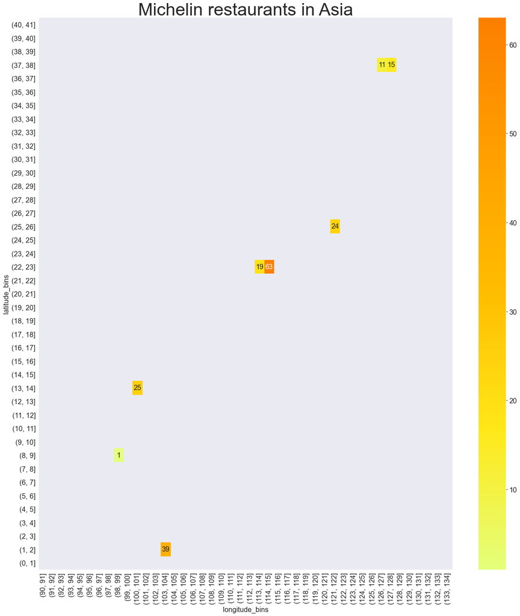

```python
fig, ax = plt.subplots(figsize = (21,23))
ax.set_title('Michelin restaurants in Asia', fontsize = 40)
ax = sns.heatmap(michelin_asia_df_pivot, annot = True, cmap = 'Wistia')
fig.savefig(r'C:\Users\ASUS\Desktop\Programming\Python\Michelin_project\heatmap_asia', transparent = True)
```

[figure not shown]

```python
asia_map = Image.open(r'C:\Users\ASUS\Desktop\Programming\Python\Michelin_project\asia_map.png')

#plt.title('Michelin restaurants in Asia')
plt.figure(figsize = (20,17))
plt.axis('off')
plt.title('Michelin restaurants in Asia', fontsize = 40)
plt.imshow(asia_map);
```

### Relationship between number of stars and prices

```python
michelin_df_copy = michelin_df.dropna().reset_index()
```

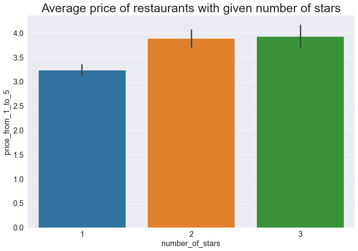

```python
plt.figure(figsize = (12,8))
plt.title('Average price of restaurants with given number of stars', fontsize = 25)
sns.barplot('number_of_stars', 'price_from_1_to_5', data = michelin_df_copy);
```

**As we see, the average price increases with the growth of number of stars of the restaurants. However the average price in restaurants with 2 stars is only marginally lower than the average price in restaurants with 3 stars**

## Asking and Answering Questions

### Q1: Which restaurant is located most notherly, most southerly, nearest to the equator?

```python
michelin_df[michelin_df['latitude'] == michelin_df['latitude'].max()]
```

|  | name | latitude | longitude | city | country | continent | cuisine | price_from_1_to_5 | number_of_stars |
| --- | --- | --- | --- | --- | --- | --- | --- | --- | --- |
| 624 | Fäviken Magasinet | 63.43626 | 13.29337 | Järpen | Sweden | Europe | Creative | 4 | 2 |

**Fäviken Magasinet in Sweden is the restaurant that is located most northerly.**

```python
michelin_df[michelin_df['latitude'] == michelin_df['latitude'].min()]
```

|  | name | latitude | longitude | city | country | continent | cuisine | price_from_1_to_5 | number_of_stars |
| --- | --- | --- | --- | --- | --- | --- | --- | --- | --- |
| 285 | Tangará Jean-Georges | -23.634005 | -46.72428 | Sao Paulo | Brazil | South America | Modern | 5 | 1 |

**Tangará Jean-Georges in Brazil, Sao Paulo is the restaurant that is located most southerly.**

```python
michelin_df[michelin_df['latitude'] == abs(michelin_df['latitude']).min()]
```

|  | name | latitude | longitude | city | country | continent | cuisine | price_from_1_to_5 | number_of_stars |
| --- | --- | --- | --- | --- | --- | --- | --- | --- | --- |
| 340 | Ma Cuisine | 1.27826 | 103.842 | Singapore | Singapore | Asia | French | 1 | 1 |

**Ma Cuisine in Singapore is the restaurant that is located the nearest to the equator.**

### Q2: On which continent is there a greatest number of Michelin restaurants and on which the smallest?

```python
michelin_df['continent'].value_counts()
```

```
Europe           278
North America    202
Asia             197
South America     18
Name: continent, dtype: int64
```

**The most Michelin restaurants are located in Europe. There are no Michelin restaurants in Africa and in Australia (and obviously in Antarctida). Among continents in which there are Michelin restaurants the smallest number of them is in South America.**

### Q3: The average price of various kinds of cuisine

```python
michelin_df_copy.info()
```

```
<class 'pandas.core.frame.DataFrame'>
RangeIndex: 519 entries, 0 to 518
Data columns (total 10 columns):
 #   Column             Non-Null Count  Dtype
---  ------             --------------  -----
 0   index              519 non-null    int64
 1   name               519 non-null    object
 2   latitude           519 non-null    float64
 3   longitude          519 non-null    float64
 4   city               519 non-null    object
 5   country            519 non-null    object
 6   continent          519 non-null    object
 7   cuisine            519 non-null    object
 8   price_from_1_to_5  519 non-null    Int8
 9   number_of_stars    519 non-null    int8
dtypes: Int8(1), float64(2), int64(1), int8(1), object(5)
memory usage: 34.1+ KB
```

```python
michelin_cuisine_price = michelin_df_copy.groupby('cuisine').agg({'cuisine': 'count', 'price_from_1_to_5': 'mean'})

michelin_cuisine_price = michelin_cuisine_price[michelin_cuisine_price['cuisine'] >= 10]

michelin_cuisine_price.rename(columns = {'cuisine': 'number_of_restaurants'}, inplace = True)

michelin_cuisine_price['price_from_1_to_5'] = round(michelin_cuisine_price['price_from_1_to_5'],1)

michelin_cuisine_price.sort_values('price_from_1_to_5', ascending = False, inplace = True)

michelin_cuisine_price
```

| cuisine | number_of_restaurants | price_from_1_to_5 |
| --- | --- | --- |
| Creative | 35 | 4.1 |
| Sushi | 17 | 4.0 |
| Japanese | 54 | 3.9 |
| Modern | 53 | 3.8 |
| Contemporary | 75 | 3.7 |
| Innovative | 28 | 3.5 |
| French | 38 | 3.4 |
| Italian | 19 | 3.4 |
| Korean | 17 | 3.4 |
| Californian | 14 | 3.3 |
| American | 10 | 3.1 |
| Thai | 16 | 2.9 |
| Chinese | 61 | 2.0 |

**Among kinds of cuisine that are characteristic for at least 10 restaurants creative cuisine is the most expensive one and Chinese cuisine is the cheapest one.**

### Q4: The average price of restaurants in particular cities, countries and continents

```python
michelin_city_price = michelin_df_copy.groupby('city').agg({'city': 'count', 'price_from_1_to_5': 'mean'})

michelin_city_price = michelin_city_price[michelin_city_price['city'] >= 10]

michelin_city_price.rename(columns = {'city': 'number_of_restaurants'}, inplace = True)

michelin_city_price['price_from_1_to_5'] = round(michelin_city_price['price_from_1_to_5'],1)

michelin_city_price.sort_values('price_from_1_to_5', ascending = False, inplace = True)

michelin_city_price
```

| city | number_of_restaurants | price_from_1_to_5 |
| --- | --- | --- |
| Wien | 13 | 4.9 |
| Sao Paulo | 12 | 4.8 |
| Los Angeles | 24 | 3.7 |
| New York | 74 | 3.6 |
| Bangkok | 25 | 3.5 |
| Chicago | 22 | 3.5 |
| San Francisco | 55 | 3.5 |
| Stockholm | 10 | 3.5 |
| Seoul | 26 | 3.2 |
| Washington | 16 | 3.2 |
| Hong Kong | 63 | 3.0 |
| København | 17 | 3.0 |
| Taipei | 24 | 2.8 |
| Macau | 19 | 2.5 |
| Singapore | 39 | 2.1 |

**The city with the highest average price of restaurants with Michelin star(s) is Wien. The city with the lowest average price is Singapore.**

```python
michelin_country_price = michelin_df_copy.groupby('country').agg({'country': 'count', 'price_from_1_to_5': 'mean'})

michelin_country_price = michelin_country_price[michelin_country_price['country'] >= 10]

michelin_country_price.rename(columns = {'country': 'number_of_restaurants'}, inplace = True)

michelin_country_price['price_from_1_to_5'] = round(michelin_country_price['price_from_1_to_5'],1)

michelin_country_price.sort_values('price_from_1_to_5', ascending = False, inplace = True)

michelin_country_price
```

| country | number_of_restaurants | price_from_1_to_5 |
| --- | --- | --- |
| Austria | 19 | 4.9 |
| Brazil | 18 | 4.9 |
| Thailand | 26 | 3.6 |
| United States | 202 | 3.6 |
| Sweden | 22 | 3.4 |
| South Korea | 26 | 3.2 |
| Denmark | 28 | 3.1 |
| China | 82 | 2.9 |
| Taiwan | 24 | 2.8 |
| Singapore | 39 | 2.1 |

**The country with the highest average price of restaurants with Michelin star(s) is Austria. The country with the lowest average price is Singapore.**

```python
michelin_continent_price = michelin_df_copy.groupby('continent').agg({'continent': 'count', 'price_from_1_to_5': 'mean'})

michelin_continent_price.rename(columns = {'continent': 'number_of_restaurants'}, inplace = True)

michelin_continent_price['price_from_1_to_5'] = round(michelin_continent_price['price_from_1_to_5'],1)

michelin_continent_price.sort_values('price_from_1_to_5', ascending = False, inplace = True)

michelin_continent_price
```

| continent | number_of_restaurants | price_from_1_to_5 |
| --- | --- | --- |
| South America | 18 | 4.9 |
| Europe | 102 | 3.9 |
| North America | 202 | 3.6 |
| Asia | 197 | 2.8 |

**The continent with the highest average price of restaurants with Michelin star(s) is South America. The continent with the lowest average price is Asia.**

**However, in South America there are only 18 restaurants with Michelin star which is much less than in remaining continents.**

### Q5: In which city are there the most 3-, 2- and 1-star restaurants?

```python
michelin_df['city'].value_counts().head(10)
```

```
New York         74
London           65
Hong Kong        63
San Francisco    55
Singapore        39
Seoul            26
Bangkok          25
Taipei           24
Los Angeles      24
Chicago          22
Name: city, dtype: int64
```

**In New York there is the greatest number of Michelin restaurants.**

```python
michelin_df[michelin_df['number_of_stars'] == 3]['city'].value_counts()
```

```
Hong Kong              7
San Francisco          6
New York               5
London                 3
Macau                  3
Bray                   2
Seoul                  2
Stockholm              1
Washington             1
Oslo                   1
Wien                   1
South San Francisco    1
Chicago                1
København              1
Taipei                 1
Name: city, dtype: int64
```

**The greatest number of restaurants with 3 Michelin stars is in Hong Kong.**

```python
michelin_df[michelin_df['number_of_stars'] == 2]['city'].value_counts().head(10)
```

```
New York         14
Hong Kong        12
London            8
San Francisco     7
Los Angeles       6
Singapore         5
Seoul             5
Macau             5
Taipei            5
Wien              4
Name: city, dtype: int64
```

**The greatest number of restaurants with 2 Michelin stars is in New York.**

```python
michelin_df[michelin_df['number_of_stars'] == 1]['city'].value_counts().head(10)
```

```
New York         55
London           54
Hong Kong        44
San Francisco    42
Singapore        34
Bangkok          21
Seoul            19
Los Angeles      18
Taipei           18
Chicago          18
Name: city, dtype: int64
```

**The greatest number of restaurants with 1 Michelin star is in New York.**

## Conclusions

The dataset downloaded from kaggle website contains the list of restaurants with Michelin star(s) and their details. In this notebook I performed scrupulous data cleaning what helped me to analyze the data.

I created the charts that present the prices of restaurants and their locations around the world. I answered also some questions that may intrigue fans of gastronomy.

I hope you enjoyed my project!